# Course - Supervised Learning

##### NOTE:

1. Your code MUST execute without any errors.
2. You can add more lines in your code as required.

## Section 1: Basic Statistical Concepts

### Question 1

**The dataset is loaded for you. Perform the following tasks:**

1. Compute basic statistical measures for each of the variables from the freeny dataset.
2. Construct a correlation matrix for all the variables in the freeny dataset.
3. Create a new variable price.income.ratio constructed as a ratio of price.index and income.level. Print its summary statistics.

```r
library(datasets)
```

```r
df = freeny
head(freeny)
```

|  | y | lag.quarterly.revenue | price.index | income.level | market.potential |
| --- | --- | --- | --- | --- | --- |
| 1962.25 | 8.79236 | 8.79636 | 4.70997 | 5.82110 | 12.9699 |
| 1962.5 | 8.79137 | 8.79236 | 4.70217 | 5.82558 | 12.9733 |
| 1962.75 | 8.81486 | 8.79137 | 4.68944 | 5.83112 | 12.9774 |
| 1963 | 8.81301 | 8.81486 | 4.68558 | 5.84046 | 12.9806 |
| 1963.25 | 8.90751 | 8.81301 | 4.64019 | 5.85036 | 12.9831 |
| 1963.5 | 8.93673 | 8.90751 | 4.62553 | 5.86464 | 12.9854 |

```r
head(df)
```

|  | y | lag.quarterly.revenue | price.index | income.level | market.potential |
| --- | --- | --- | --- | --- | --- |
| 1962.25 | 8.79236 | 8.79636 | 4.70997 | 5.82110 | 12.9699 |
| 1962.5 | 8.79137 | 8.79236 | 4.70217 | 5.82558 | 12.9733 |
| 1962.75 | 8.81486 | 8.79137 | 4.68944 | 5.83112 | 12.9774 |
| 1963 | 8.81301 | 8.81486 | 4.68558 | 5.84046 | 12.9806 |
| 1963.25 | 8.90751 | 8.81301 | 4.64019 | 5.85036 | 12.9831 |
| 1963.5 | 8.93673 | 8.90751 | 4.62553 | 5.86464 | 12.9854 |

# Question # 01

```r
colnames(df)
```

1. 'y'

2. 'lag.quarterly.revenue'

3. 'price.index'

4. 'income.level'

5. 'market.potential'

```r
mean(df$lag.quarterly.revenue)
```

9.28071769230769

```r
median(df$price.index)
```

4.51018

```r
mean(df$income.level)
```

6.0385958974359

```r
mean(df$market.potential)
```

13.0668307692308

# Question # 02

```r
library(pacman, readxl, ggplot2, dplyr, tidyverse, forecast,
       tsfeatures, smooth, car, psych, astsa, writexl, Hmisc,
       tsoutliers, leaps, fabletools, FactoMineR, TSA)
```

```
Error in library(pacman, readxl, ggplot2, dplyr, tidyverse, forecast, : unused arguments (tsoutliers, leaps, fabletools, FactoMineR, TSA)
Traceback:
```

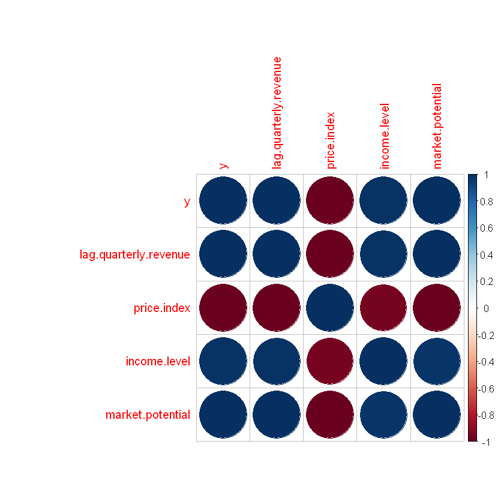

```r
library(corrplot)
df <- as.data.frame(freeny)
M <-cor(df)
#corrplot(df)
corrplot(M)
```

# Question # 03

```r
head(df)
```

|  | y | lag.quarterly.revenue | price.index | income.level | market.potential |
| --- | --- | --- | --- | --- | --- |
| 1962.25 | 8.79236 | 8.79636 | 4.70997 | 5.82110 | 12.9699 |
| 1962.5 | 8.79137 | 8.79236 | 4.70217 | 5.82558 | 12.9733 |
| 1962.75 | 8.81486 | 8.79137 | 4.68944 | 5.83112 | 12.9774 |
| 1963 | 8.81301 | 8.81486 | 4.68558 | 5.84046 | 12.9806 |
| 1963.25 | 8.90751 | 8.81301 | 4.64019 | 5.85036 | 12.9831 |
| 1963.5 | 8.93673 | 8.90751 | 4.62553 | 5.86464 | 12.9854 |

```r
df$price.index/df$income.level
```

1. 0.809120269364897

2. 0.807159115487213

3. 0.804209139925092

4. 0.802262150584029

5. 0.793146062806391

6. 0.788715078845419

7. 0.786007768357977

8. 0.782778845061491

9. 0.778648742604299

10. 0.775397487849863

11. 0.773016552870928

12. 0.769912098235255

13. 0.76545361781852

14. 0.763954981619882

15. 0.759746130328833

16. 0.757572393222586

17. 0.755256612784109

18. 0.751853578075055

19. 0.749644545654209

20. 0.74413992572097

21. 0.741804932606164

22. 0.739057067389452

23. 0.733348334094321

24. 0.729145737701963

25. 0.726375843208602

26. 0.72274017488669

27. 0.720534397161383

28. 0.720599477295002

29. 0.717332198154029

30. 0.713371454600174

31. 0.710701145390486

32. 0.702974365971603

33. 0.701024219746411

34. 0.697976412809843

35. 0.699374325431927

36. 0.696425769655679

37. 0.694326468078504

38. 0.690757002601001

39. 0.689948873441608

```r
df$price.income.ratio <- df$price.index/df$income.level
```

```r
head(df)
```

|  | y | lag.quarterly.revenue | price.index | income.level | market.potential | price.income.ratio |
| --- | --- | --- | --- | --- | --- | --- |
| 1962.25 | 8.79236 | 8.79636 | 4.70997 | 5.82110 | 12.9699 | 0.8091203 |
| 1962.5 | 8.79137 | 8.79236 | 4.70217 | 5.82558 | 12.9733 | 0.8071591 |
| 1962.75 | 8.81486 | 8.79137 | 4.68944 | 5.83112 | 12.9774 | 0.8042091 |
| 1963 | 8.81301 | 8.81486 | 4.68558 | 5.84046 | 12.9806 | 0.8022622 |
| 1963.25 | 8.90751 | 8.81301 | 4.64019 | 5.85036 | 12.9831 | 0.7931461 |
| 1963.5 | 8.93673 | 8.90751 | 4.62553 | 5.86464 | 12.9854 | 0.7887151 |

### Good Job! You are done with the section!

## Section 2: Machine Learning: Regression Analysis

### Question 1

**Based on the observations acquired from the above exercise:**

1. Construct a linear regression model using y as dependent variable and top 2 variables with the highest correlation with y as dependent variable.
2. Calculate the r-squared value for the constructed model.
3. Use half the dataset for training and the remaining for testing.
4. Generate in-sample and out-sample predictions and compute variance of residuals [hint: residual= y_predicted - y_observed]
5. Plot the actual and predicted results for y variable.

# Question # 01

```r
head(df)
```

|  | y | lag.quarterly.revenue | price.index | income.level | market.potential | price.income.ratio |
| --- | --- | --- | --- | --- | --- | --- |
| 1962.25 | 8.79236 | 8.79636 | 4.70997 | 5.82110 | 12.9699 | 0.8091203 |
| 1962.5 | 8.79137 | 8.79236 | 4.70217 | 5.82558 | 12.9733 | 0.8071591 |
| 1962.75 | 8.81486 | 8.79137 | 4.68944 | 5.83112 | 12.9774 | 0.8042091 |
| 1963 | 8.81301 | 8.81486 | 4.68558 | 5.84046 | 12.9806 | 0.8022622 |
| 1963.25 | 8.90751 | 8.81301 | 4.64019 | 5.85036 | 12.9831 | 0.7931461 |
| 1963.5 | 8.93673 | 8.90751 | 4.62553 | 5.86464 | 12.9854 | 0.7887151 |

```r
model <- lm(y ~ lag.quarterly.revenue+price.index, data= df)
```

```r
model
```

```
Call:
lm(formula = y ~ lag.quarterly.revenue + price.index, data = df)

Coefficients:
          (Intercept)  lag.quarterly.revenue            price.index
               2.1858                 0.8912                -0.2559
```

# Question # 02

```r
summary(model)
```

```
Call:
lm(formula = y ~ lag.quarterly.revenue + price.index, data = df)

Residuals:
      Min        1Q    Median        3Q       Max
-0.040656 -0.007613 -0.001472  0.015284  0.054893

Coefficients:
                      Estimate Std. Error t value Pr(>|t|)
(Intercept)            2.18577    1.47236   1.485    0.146
lag.quarterly.revenue  0.89122    0.07412  12.024 3.63e-14 ***
price.index           -0.25592    0.17534  -1.460    0.153
---
Signif. codes:  0 '***' 0.001 '**' 0.01 '*' 0.05 '.' 0.1 ' ' 1

Residual standard error: 0.02091 on 36 degrees of freedom
Multiple R-squared:  0.9958,	Adjusted R-squared:  0.9956
F-statistic:  4309 on 2 and 36 DF,  p-value: < 2.2e-16
```

# Question # 03

```r
set.seed(100)
trainrow <- sample(1:nrow(df),0.7*nrow(df))
train_data <- df[trainrow,]
test_data <- df[-trainrow,]
```

```r
head(train_data)
```

|  | y | lag.quarterly.revenue | price.index | income.level | market.potential | price.income.ratio |
| --- | --- | --- | --- | --- | --- | --- |
| 1964.5 | 9.03049 | 9.00868 | 4.60766 | 5.94232 | 13.0033 | 0.7753975 |
| 1971.5 | 9.77536 | 9.74924 | 4.27839 | 6.19377 | 13.1625 | 0.6907570 |
| 1968.25 | 9.44223 | 9.42150 | 4.43966 | 6.11207 | 13.0950 | 0.7263758 |
| 1965.5 | 9.12685 | 9.10698 | 4.58661 | 6.00377 | 13.0265 | 0.7639550 |
| 1967.75 | 9.39767 | 9.35835 | 4.46505 | 6.08858 | 13.0849 | 0.7333483 |
| 1967.5 | 9.35835 | 9.35025 | 4.49360 | 6.08018 | 13.0770 | 0.7390571 |

```r
dim(train_data)
```

1. 27

2. 6

```r
dim(test_data)
```

1. 12

2. 6

```r
modelf <- lm(y ~ lag.quarterly.revenue+price.index+income.level+market.potential+price.income.ratio, data = train_data)
```

```r
modelf
```

```
Call:
lm(formula = y ~ lag.quarterly.revenue + price.index + income.level +
    market.potential + price.income.ratio, data = train_data)

Coefficients:
          (Intercept)  lag.quarterly.revenue            price.index
              -2.4962                 0.3131                 1.4613
         income.level       market.potential     price.income.ratio
              -1.0983                 1.3881               -12.3193
```

```r
summary(modelf)
```

```
Call:
lm(formula = y ~ lag.quarterly.revenue + price.index + income.level +
    market.potential + price.income.ratio, data = train_data)

Residuals:
      Min        1Q    Median        3Q       Max
-0.026159 -0.010000  0.001737  0.008903  0.025399

Coefficients:
                      Estimate Std. Error t value Pr(>|t|)
(Intercept)            -2.4962     8.5398  -0.292    0.773
lag.quarterly.revenue   0.3131     0.2759   1.135    0.269
price.index             1.4613     2.7797   0.526    0.605
income.level           -1.0983     2.4438  -0.449    0.658
market.potential        1.3881     1.1299   1.229    0.233
price.income.ratio    -12.3193    17.4784  -0.705    0.489

Residual standard error: 0.0159 on 21 degrees of freedom
Multiple R-squared:  0.9979,	Adjusted R-squared:  0.9974
F-statistic:  1966 on 5 and 21 DF,  p-value: < 2.2e-16
```

```r
AIC(modelf)
```

-139.805655691046

```r
ypred <- predict(modelf, test_data)
```

```r
actuals_preds <- data.frame(cbind(actuals=test_data$y, predecteds = ypred))
```

```r
head(actuals_preds)
```

|  | actuals | predecteds |
| --- | --- | --- |
| 1962.25 | 8.79236 | 8.782392 |
| 1963.25 | 8.90751 | 8.868611 |
| 1964.25 | 9.00868 | 8.994755 |
| 1965.25 | 9.10698 | 9.105412 |
| 1966 | 9.18665 | 9.199416 |
| 1966.25 | 9.23823 | 9.221897 |

```r
correlation_accuracy <- cor(actuals_preds)
correlation_accuracy
```

|  | actuals | predecteds |
| --- | --- | --- |
| actuals | 1.0000000 | 0.9993458 |
| predecteds | 0.9993458 | 1.0000000 |

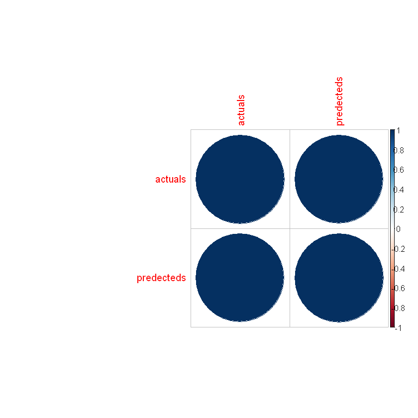

```r
corrplot(correlation_accuracy)
```

```r
mape <- mean(abs((actuals_preds$predecteds - actuals_preds$actual))/ actuals_preds$actuals)
```

```r
mape
```

0.00127517895934415

# Question # 04

```r
residual <- actuals_preds$predecteds - actuals_preds$actual
residual <- data.frame(residual)
head(cbind(actuals_preds,residual))
```

|  | actuals | predecteds | residual |
| --- | --- | --- | --- |
| 1962.25 | 8.79236 | 8.782392 | -0.009967715 |
| 1963.25 | 8.90751 | 8.868611 | -0.038899306 |
| 1964.25 | 9.00868 | 8.994755 | -0.013925408 |
| 1965.25 | 9.10698 | 9.105412 | -0.001567691 |
| 1966 | 9.18665 | 9.199416 | 0.012766037 |
| 1966.25 | 9.23823 | 9.221897 | -0.016332994 |

# Question # 05

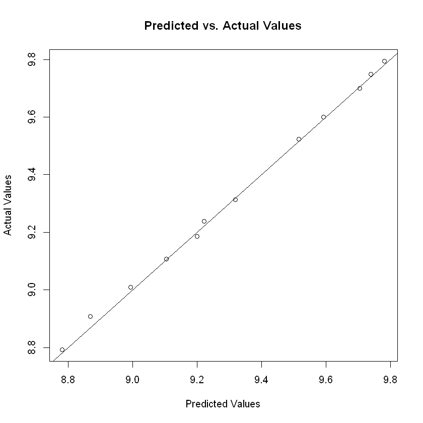

```r
plot(x=actuals_preds$predecteds, y= actuals_preds$actuals,
     xlab='Predicted Values',
     ylab='Actual Values',
     main='Predicted vs. Actual Values')
abline(a=0, b=1)
```

```r
modelf
```

```
Call:
lm(formula = y ~ lag.quarterly.revenue + price.index + income.level +
    market.potential + price.income.ratio, data = train_data)

Coefficients:
          (Intercept)  lag.quarterly.revenue            price.index
              -2.4962                 0.3131                 1.4613
         income.level       market.potential     price.income.ratio
              -1.0983                 1.3881               -12.3193
```

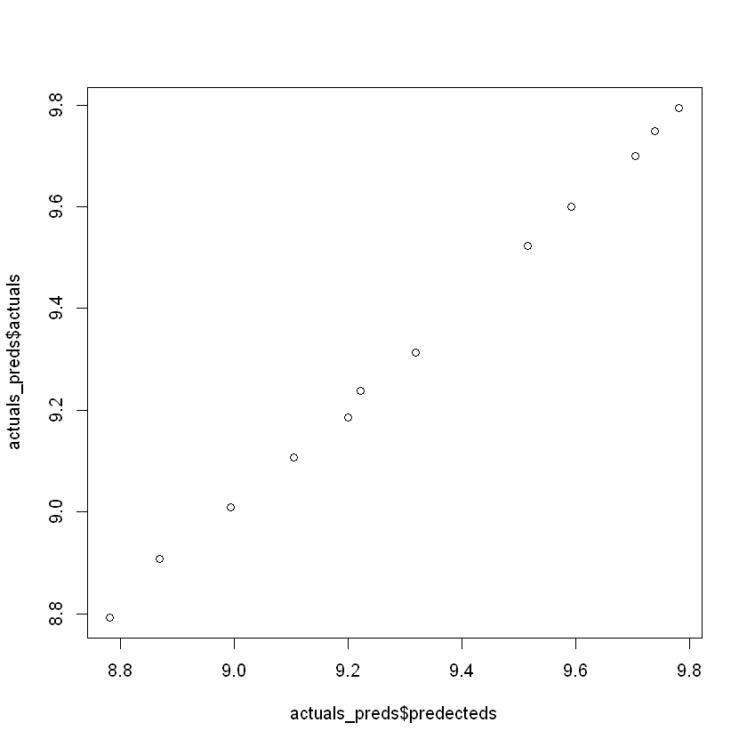

```r
plot(actuals_preds$predecteds,actuals_preds$actuals)
```

### Good Job! You are done with the section!

## Section 3: Machine Learning: Logistic Regression

## Question 1

**Construct a logistic regression model using the Smarket dataset:**

1. Your task is to predict the direction [Up: 1, Down:0].
2. Use a combination of variables that produces the lowest residual variance.
3. Plot the predicted vs. actual values.
4. Construct variable importance plot for all the variables.

```r
#install.packages('ISLR')
require('ISLR')
head(Smarket)
df <- Smarket
```

| Year | Lag1 | Lag2 | Lag3 | Lag4 | Lag5 | Volume | Today | Direction |
| --- | --- | --- | --- | --- | --- | --- | --- | --- |
| 2001 | 0.381 | -0.192 | -2.624 | -1.055 | 5.010 | 1.1913 | 0.959 | Up |
| 2001 | 0.959 | 0.381 | -0.192 | -2.624 | -1.055 | 1.2965 | 1.032 | Up |
| 2001 | 1.032 | 0.959 | 0.381 | -0.192 | -2.624 | 1.4112 | -0.623 | Down |
| 2001 | -0.623 | 1.032 | 0.959 | 0.381 | -0.192 | 1.2760 | 0.614 | Up |
| 2001 | 0.614 | -0.623 | 1.032 | 0.959 | 0.381 | 1.2057 | 0.213 | Up |
| 2001 | 0.213 | 0.614 | -0.623 | 1.032 | 0.959 | 1.3491 | 1.392 | Up |

```r
head(df)
```

| Year | Lag1 | Lag2 | Lag3 | Lag4 | Lag5 | Volume | Today | Direction |
| --- | --- | --- | --- | --- | --- | --- | --- | --- |
| 2001 | 0.381 | -0.192 | -2.624 | -1.055 | 5.010 | 1.1913 | 0.959 | Up |
| 2001 | 0.959 | 0.381 | -0.192 | -2.624 | -1.055 | 1.2965 | 1.032 | Up |
| 2001 | 1.032 | 0.959 | 0.381 | -0.192 | -2.624 | 1.4112 | -0.623 | Down |
| 2001 | -0.623 | 1.032 | 0.959 | 0.381 | -0.192 | 1.2760 | 0.614 | Up |
| 2001 | 0.614 | -0.623 | 1.032 | 0.959 | 0.381 | 1.2057 | 0.213 | Up |
| 2001 | 0.213 | 0.614 | -0.623 | 1.032 | 0.959 | 1.3491 | 1.392 | Up |

```r
m <- data.frame(df$Year,df$Lag1,df$Lag2,df$Lag3,df$Lag4,df$Lag5,df$Volume,df$Today)
f <- cor(m)
f
```

|  | df.Year | df.Lag1 | df.Lag2 | df.Lag3 | df.Lag4 | df.Lag5 | df.Volume | df.Today |
| --- | --- | --- | --- | --- | --- | --- | --- | --- |
| df.Year | 1.00000000 | 0.029699649 | 0.030596422 | 0.033194581 | 0.035688718 | 0.029787995 | 0.53900647 | 0.030095229 |
| df.Lag1 | 0.02969965 | 1.000000000 | -0.026294328 | -0.010803402 | -0.002985911 | -0.005674606 | 0.04090991 | -0.026155045 |
| df.Lag2 | 0.03059642 | -0.026294328 | 1.000000000 | -0.025896670 | -0.010853533 | -0.003557949 | -0.04338321 | -0.010250033 |
| df.Lag3 | 0.03319458 | -0.010803402 | -0.025896670 | 1.000000000 | -0.024051036 | -0.018808338 | -0.04182369 | -0.002447647 |
| df.Lag4 | 0.03568872 | -0.002985911 | -0.010853533 | -0.024051036 | 1.000000000 | -0.027083641 | -0.04841425 | -0.006899527 |
| df.Lag5 | 0.02978799 | -0.005674606 | -0.003557949 | -0.018808338 | -0.027083641 | 1.000000000 | -0.02200231 | -0.034860083 |
| df.Volume | 0.53900647 | 0.040909908 | -0.043383215 | -0.041823686 | -0.048414246 | -0.022002315 | 1.00000000 | 0.014591823 |
| df.Today | 0.03009523 | -0.026155045 | -0.010250033 | -0.002447647 | -0.006899527 | -0.034860083 | 0.01459182 | 1.000000000 |

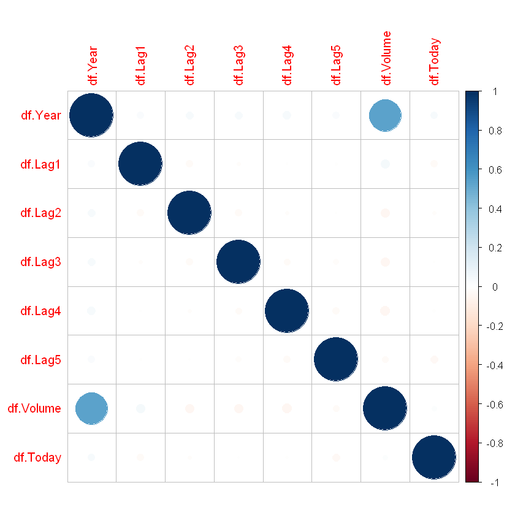

```r
library(corrplot)
corrplot(f)
```

```r
library(psych)
library(corrplot)
library(RColorBrewer)
```

```
Error in library(psych): there is no package called 'psych'
Traceback:

1. library(psych)
```

```r
#install.packages("psych")
```

# Question # 01

```r
require('ISLR')
head(Smarket)
df <- Smarket
```

| Year | Lag1 | Lag2 | Lag3 | Lag4 | Lag5 | Volume | Today | Direction |
| --- | --- | --- | --- | --- | --- | --- | --- | --- |
| 2001 | 0.381 | -0.192 | -2.624 | -1.055 | 5.010 | 1.1913 | 0.959 | Up |
| 2001 | 0.959 | 0.381 | -0.192 | -2.624 | -1.055 | 1.2965 | 1.032 | Up |
| 2001 | 1.032 | 0.959 | 0.381 | -0.192 | -2.624 | 1.4112 | -0.623 | Down |
| 2001 | -0.623 | 1.032 | 0.959 | 0.381 | -0.192 | 1.2760 | 0.614 | Up |
| 2001 | 0.614 | -0.623 | 1.032 | 0.959 | 0.381 | 1.2057 | 0.213 | Up |
| 2001 | 0.213 | 0.614 | -0.623 | 1.032 | 0.959 | 1.3491 | 1.392 | Up |

```r
library(dplyr)
```

```r
glimpse(df)
```

```
Observations: 1,250
Variables: 9
$ Year      <dbl> 2001, 2001, 2001, 2001, 2001, 2001, 2001, 2001, 2001, 200...
$ Lag1      <dbl> 0.381, 0.959, 1.032, -0.623, 0.614, 0.213, 1.392, -0.403,...
$ Lag2      <dbl> -0.192, 0.381, 0.959, 1.032, -0.623, 0.614, 0.213, 1.392,...
$ Lag3      <dbl> -2.624, -0.192, 0.381, 0.959, 1.032, -0.623, 0.614, 0.213...
$ Lag4      <dbl> -1.055, -2.624, -0.192, 0.381, 0.959, 1.032, -0.623, 0.61...
$ Lag5      <dbl> 5.010, -1.055, -2.624, -0.192, 0.381, 0.959, 1.032, -0.62...
$ Volume    <dbl> 1.1913, 1.2965, 1.4112, 1.2760, 1.2057, 1.3491, 1.4450, 1...
$ Today     <dbl> 0.959, 1.032, -0.623, 0.614, 0.213, 1.392, -0.403, 0.027,...
$ Direction <fct> Up, Up, Down, Up, Up, Up, Down, Up, Up, Up, Down, Down, U...
```

```r
str(df)
```

```
'data.frame':	1250 obs. of  9 variables:
 $ Year     : num  2001 2001 2001 2001 2001 ...
 $ Lag1     : num  0.381 0.959 1.032 -0.623 0.614 ...
 $ Lag2     : num  -0.192 0.381 0.959 1.032 -0.623 ...
 $ Lag3     : num  -2.624 -0.192 0.381 0.959 1.032 ...
 $ Lag4     : num  -1.055 -2.624 -0.192 0.381 0.959 ...
 $ Lag5     : num  5.01 -1.055 -2.624 -0.192 0.381 ...
 $ Volume   : num  1.19 1.3 1.41 1.28 1.21 ...
 $ Today    : num  0.959 1.032 -0.623 0.614 0.213 ...
 $ Direction: Factor w/ 2 levels "Down","Up": 2 2 1 2 2 2 1 2 2 2 ...
```

```r
df$tar <- factor(df$Direction, levels=c("Up", "Down"), labels=c(1, 0))
df$tar <- as.integer(df$tar)
df["tar"][df["tar"] == 1] <- 1
df["tar"][df["tar"] == 2] <- 0
```

```r
#df$Direction <- factor(df$Direction)
str(df)
```

```
'data.frame':	1250 obs. of  10 variables:
 $ Year     : num  2001 2001 2001 2001 2001 ...
 $ Lag1     : num  0.381 0.959 1.032 -0.623 0.614 ...
 $ Lag2     : num  -0.192 0.381 0.959 1.032 -0.623 ...
 $ Lag3     : num  -2.624 -0.192 0.381 0.959 1.032 ...
 $ Lag4     : num  -1.055 -2.624 -0.192 0.381 0.959 ...
 $ Lag5     : num  5.01 -1.055 -2.624 -0.192 0.381 ...
 $ Volume   : num  1.19 1.3 1.41 1.28 1.21 ...
 $ Today    : num  0.959 1.032 -0.623 0.614 0.213 ...
 $ Direction: Factor w/ 2 levels "Down","Up": 2 2 1 2 2 2 1 2 2 2 ...
 $ tar      : num  1 1 0 1 1 1 0 1 1 1 ...
```

```r
summary(df$Direction)
levels(df$Direction)
```

**Down**

602

**Up**

648

1. 'Down'

2. 'Up'

```r
dim(df)
```

1. 1250

2. 10

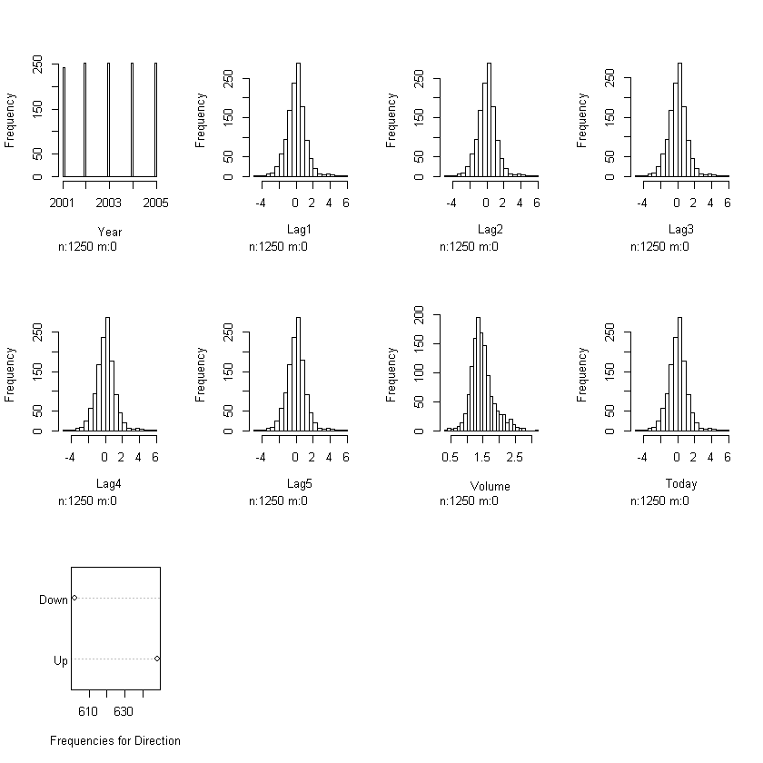

```r
library(Hmisc)
hist.data.frame(df)
```

```r
#boxplot(train_data, ylab = '')
```

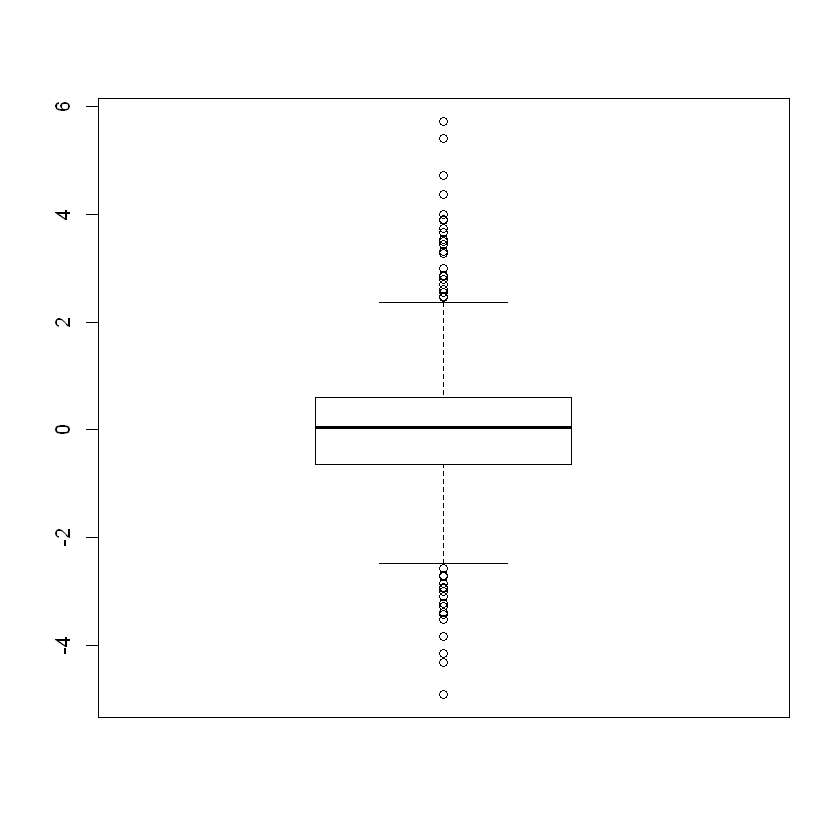

```r
boxplot(df$Lag1, ylab = '')
```

```r
continuous <-select_if(df, is.numeric)
summary(continuous)
```

```
      Year           Lag1                Lag2                Lag3
 Min.   :2001   Min.   :-4.922000   Min.   :-4.922000   Min.   :-4.922000
 1st Qu.:2002   1st Qu.:-0.639500   1st Qu.:-0.639500   1st Qu.:-0.640000
 Median :2003   Median : 0.039000   Median : 0.039000   Median : 0.038500
 Mean   :2003   Mean   : 0.003834   Mean   : 0.003919   Mean   : 0.001716
 3rd Qu.:2004   3rd Qu.: 0.596750   3rd Qu.: 0.596750   3rd Qu.: 0.596750
 Max.   :2005   Max.   : 5.733000   Max.   : 5.733000   Max.   : 5.733000
      Lag4                Lag5              Volume           Today
 Min.   :-4.922000   Min.   :-4.92200   Min.   :0.3561   Min.   :-4.922000
 1st Qu.:-0.640000   1st Qu.:-0.64000   1st Qu.:1.2574   1st Qu.:-0.639500
 Median : 0.038500   Median : 0.03850   Median :1.4229   Median : 0.038500
 Mean   : 0.001636   Mean   : 0.00561   Mean   :1.4783   Mean   : 0.003138
 3rd Qu.: 0.596750   3rd Qu.: 0.59700   3rd Qu.:1.6417   3rd Qu.: 0.596750
 Max.   : 5.733000   Max.   : 5.73300   Max.   :3.1525   Max.   : 5.733000
      tar
 Min.   :0.0000
 1st Qu.:0.0000
 Median :1.0000
 Mean   :0.5184
 3rd Qu.:1.0000
 Max.   :1.0000
```

```r
head(continuous)
```

| Year | Lag1 | Lag2 | Lag3 | Lag4 | Lag5 | Volume | Today | tar |
| --- | --- | --- | --- | --- | --- | --- | --- | --- |
| 2001 | 0.381 | -0.192 | -2.624 | -1.055 | 5.010 | 1.1913 | 0.959 | 1 |
| 2001 | 0.959 | 0.381 | -0.192 | -2.624 | -1.055 | 1.2965 | 1.032 | 1 |
| 2001 | 1.032 | 0.959 | 0.381 | -0.192 | -2.624 | 1.4112 | -0.623 | 0 |
| 2001 | -0.623 | 1.032 | 0.959 | 0.381 | -0.192 | 1.2760 | 0.614 | 1 |
| 2001 | 0.614 | -0.623 | 1.032 | 0.959 | 0.381 | 1.2057 | 0.213 | 1 |
| 2001 | 0.213 | 0.614 | -0.623 | 1.032 | 0.959 | 1.3491 | 1.392 | 1 |

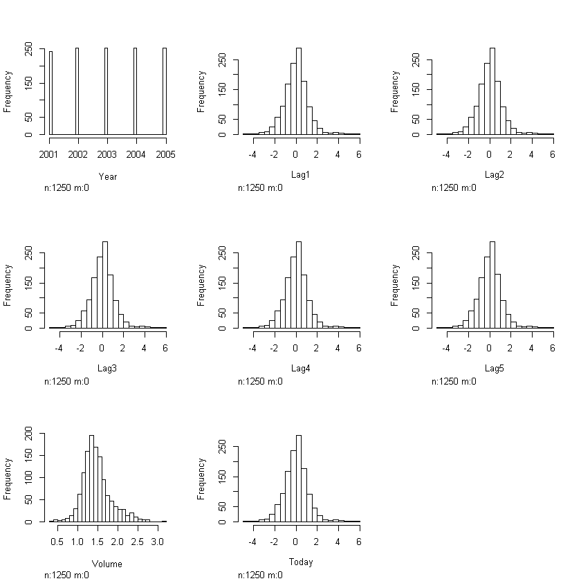

```r
library(Hmisc)
hist.data.frame(continuous)
```

```r
library(ggplot2)
```

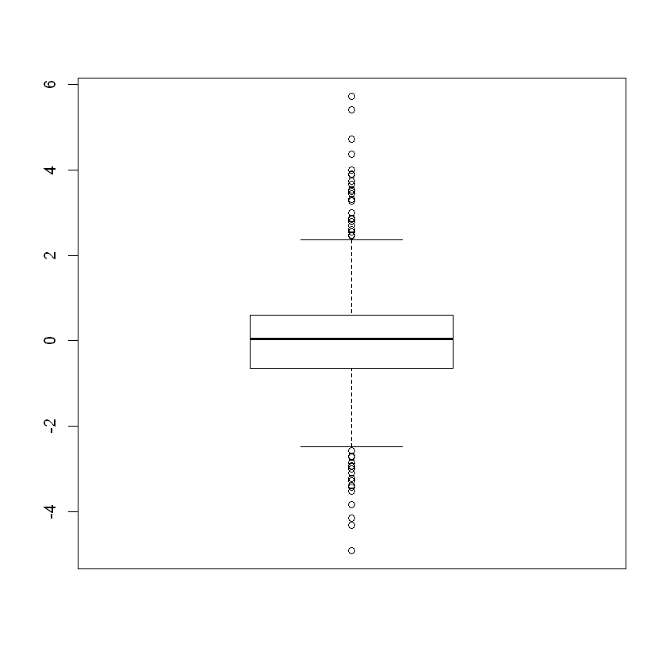

```r
boxplot(continuous$Today, ylab = '')
```

```r
print(names(continuous))
```

```
[1] "Year"   "Lag1"   "Lag2"   "Lag3"   "Lag4"   "Lag5"   "Volume" "Today"
[9] "tar"
```

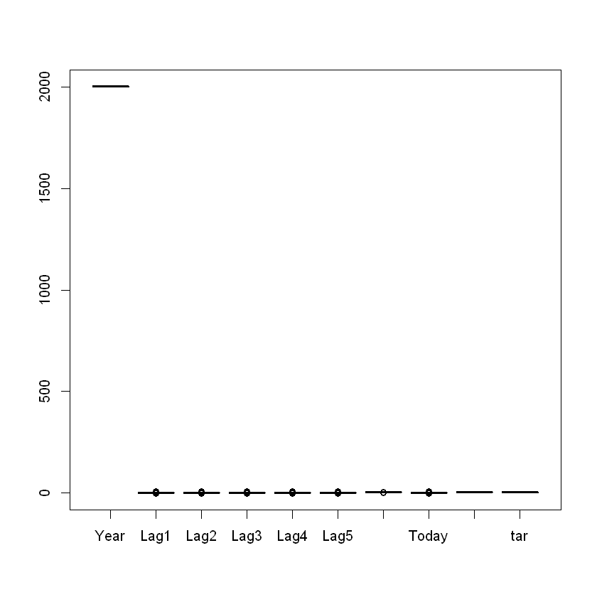

```r
a <- boxplot(df)$out
```

```r
# create detect outlier function
detect_outlier <- function(x) {
    # calculate first quantile
    Quantile1 <- quantile(x, probs=.25)

    # calculate third quantile
    Quantile3 <- quantile(x, probs=.75)

    # calculate inter quartile range
    IQR = Quantile3-Quantile1

    # return true or false
    x > Quantile3 + (IQR*1.5) | x < Quantile1 - (IQR*1.5)
}
```

```r
# create remove outlier function
remove_outlier <- function(dataframe,
                           columns=names(dataframe)) {

    # for loop to traverse in columns vector
    for (col in columns) {

        # remove observation if it satisfies outlier function
        dataframe <- dataframe[!detect_outlier(dataframe[[col]]), ]
    }

    # return dataframe
    print("Remove outliers")
    print(dataframe)
}
```

```r
print(names(continuous))
```

```
[1] "Year"   "Lag1"   "Lag2"   "Lag3"   "Lag4"   "Lag5"   "Volume" "Today"
[9] "tar"
```

```r
col <- c(names(continuous))
print(col)
```

```
[1] "Year"   "Lag1"   "Lag2"   "Lag3"   "Lag4"   "Lag5"   "Volume" "Today"
[9] "tar"
```

```r
re <- remove_outlier(df, col)#c("Year", "Lag1","Lag2", "Lag3", "Lag4", "Lag5", "Volume", "Today"))
```

[output not shown]

[output cut: 964 more lines]

```r
head(re)
```

|  | Year | Lag1 | Lag2 | Lag3 | Lag4 | Lag5 | Volume | Today | Direction | tar |
| --- | --- | --- | --- | --- | --- | --- | --- | --- | --- | --- |
| 4 | 2001 | -0.623 | 1.032 | 0.959 | 0.381 | -0.192 | 1.2760 | 0.614 | Up | 1 |
| 5 | 2001 | 0.614 | -0.623 | 1.032 | 0.959 | 0.381 | 1.2057 | 0.213 | Up | 1 |
| 6 | 2001 | 0.213 | 0.614 | -0.623 | 1.032 | 0.959 | 1.3491 | 1.392 | Up | 1 |
| 7 | 2001 | 1.392 | 0.213 | 0.614 | -0.623 | 1.032 | 1.4450 | -0.403 | Down | 0 |
| 8 | 2001 | -0.403 | 1.392 | 0.213 | 0.614 | -0.623 | 1.4078 | 0.027 | Up | 1 |
| 9 | 2001 | 0.027 | -0.403 | 1.392 | 0.213 | 0.614 | 1.1640 | 1.303 | Up | 1 |

```r
df_final <- re
```

```r
head(df_final)
```

|  | Year | Lag1 | Lag2 | Lag3 | Lag4 | Lag5 | Volume | Today | Direction | tar |
| --- | --- | --- | --- | --- | --- | --- | --- | --- | --- | --- |
| 4 | 2001 | -0.623 | 1.032 | 0.959 | 0.381 | -0.192 | 1.2760 | 0.614 | Up | 1 |
| 5 | 2001 | 0.614 | -0.623 | 1.032 | 0.959 | 0.381 | 1.2057 | 0.213 | Up | 1 |
| 6 | 2001 | 0.213 | 0.614 | -0.623 | 1.032 | 0.959 | 1.3491 | 1.392 | Up | 1 |
| 7 | 2001 | 1.392 | 0.213 | 0.614 | -0.623 | 1.032 | 1.4450 | -0.403 | Down | 0 |
| 8 | 2001 | -0.403 | 1.392 | 0.213 | 0.614 | -0.623 | 1.4078 | 0.027 | Up | 1 |
| 9 | 2001 | 0.027 | -0.403 | 1.392 | 0.213 | 0.614 | 1.1640 | 1.303 | Up | 1 |

```r
dim(df)
```

1. 1250

2. 10

```r
dim(df_final)
```

1. 977

2. 10

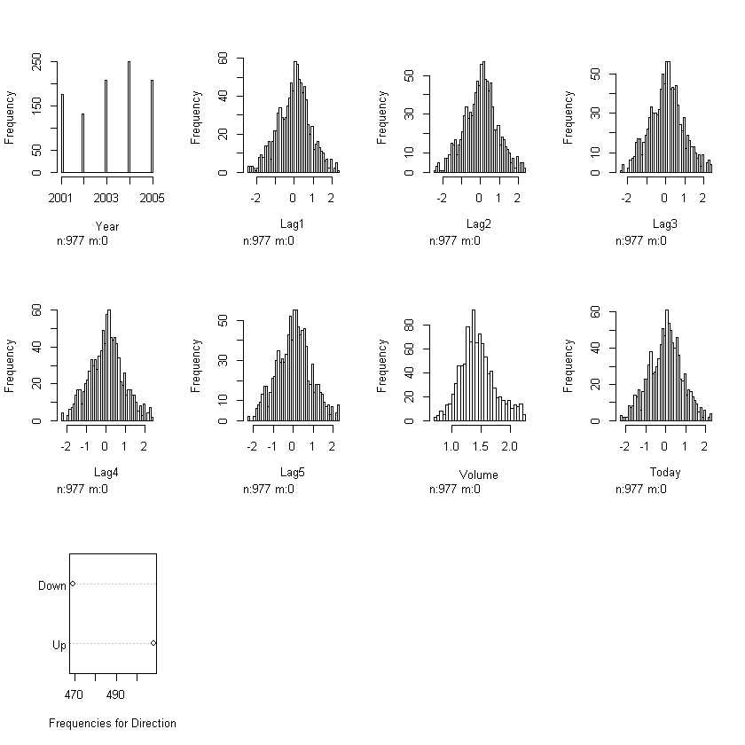

```r
library(Hmisc)
hist.data.frame(df_final)
```

```r
factor <- data.frame(select_if(df_final, is.factor))
ncol(factor)
```

1

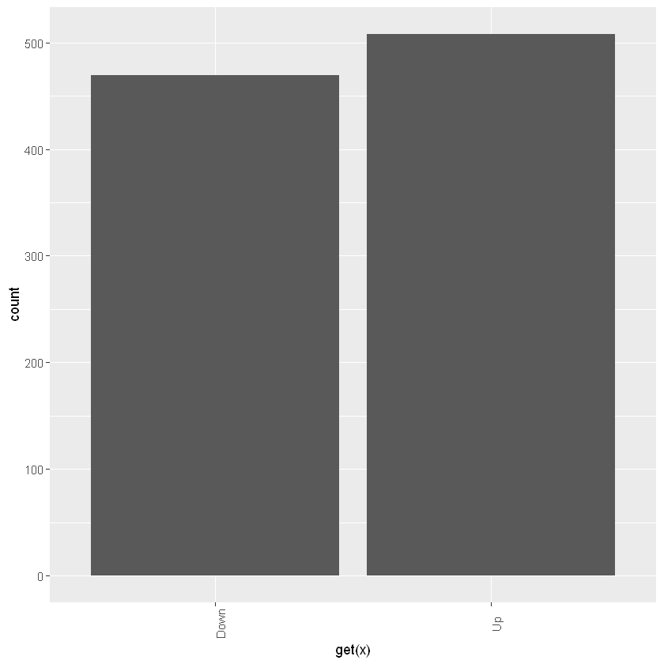

```r
library(ggplot2)
# Create graph for each column
graph <- lapply(names(factor),
    function(x)
        ggplot(factor, aes(get(x))) +
                geom_bar() +
                theme(axis.text.x = element_text(angle = 90)))
graph
```

```r
set.seed(0)
trainrow <- sample(1:nrow(df_final),0.80*nrow(df_final))
train_data <- df_final[trainrow,]
test_data <- df_final[-trainrow,]
```

```r
dim(train_data)
```

1. 781

2. 10

```r
dim(test_data)
```

1. 196

2. 10

```r
train_data
```

|  | Year | Lag1 | Lag2 | Lag3 | Lag4 | Lag5 | Volume | Today | Direction | tar |
| --- | --- | --- | --- | --- | --- | --- | --- | --- | --- | --- |
| 621 | 2003 | 1.164 | 0.802 | -0.176 | -0.974 | 1.077 | 1.51930 | -0.810 | Down | 0 |
| 1067 | 2005 | 0.001 | -0.834 | 0.597 | 0.227 | 0.448 | 1.52531 | 0.555 | Up | 1 |
| 906 | 2004 | -0.360 | 1.244 | 0.220 | 1.366 | 0.148 | 1.24940 | 0.652 | Up | 1 |
| 188 | 2001 | 1.521 | 2.294 | -0.536 | -0.834 | 0.164 | 1.70458 | -0.527 | Down | 0 |
| 1171 | 2005 | 0.241 | 1.262 | -0.292 | 0.103 | 0.986 | 2.06770 | -0.379 | Down | 0 |
| 734 | 2003 | 1.148 | -0.107 | -0.853 | 0.735 | -0.768 | 1.44110 | 0.274 | Up | 1 |
| 695 | 2003 | 0.316 | -0.259 | 0.395 | 0.702 | -0.065 | 1.41770 | -1.024 | Down | 0 |
| 480 | 2002 | -2.218 | 0.627 | -1.202 | -0.344 | -1.475 | 1.32080 | 1.396 | Up | 1 |
| 367 | 2002 | -0.083 | 1.758 | -0.267 | -1.670 | 0.362 | 2.11700 | -2.139 | Down | 0 |
| 252 | 2002 | -0.628 | -0.947 | 0.122 | -0.480 | -0.359 | 1.28640 | 0.683 | Up | 1 |
| 490 | 2002 | 0.181 | 1.302 | -0.771 | -1.315 | -0.814 | 1.11210 | -0.547 | Down | 0 |
| 824 | 2004 | 1.409 | 0.531 | -1.556 | 0.107 | 0.511 | 1.82670 | 0.059 | Up | 1 |
| 410 | 2002 | -0.008 | -1.813 | -1.385 | 0.754 | -2.269 | 1.27110 | -0.188 | Down | 0 |
| 1111 | 2005 | 0.226 | -0.235 | 0.524 | -0.216 | -0.021 | 1.66135 | 0.257 | Up | 1 |
| 1204 | 2005 | 1.678 | 0.152 | -1.502 | 1.496 | -1.005 | 2.19779 | -0.237 | Down | 0 |
| 718 | 2003 | -0.908 | -0.640 | -0.762 | -0.011 | 1.143 | 1.35430 | 0.802 | Up | 1 |
| 526 | 2003 | 2.143 | -0.160 | -1.269 | -0.810 | 0.757 | 1.40460 | 1.950 | Up | 1 |
| 1004 | 2005 | -0.143 | 0.351 | -0.363 | -1.167 | -0.812 | 1.47790 | 0.342 | Up | 1 |
| 1074 | 2005 | -1.325 | 0.593 | 0.294 | -1.672 | -1.000 | 2.21705 | 1.974 | Up | 1 |
| 818 | 2004 | -0.112 | -1.376 | 0.516 | -0.106 | -0.665 | 1.54770 | 0.059 | Up | 1 |
| 952 | 2004 | -0.086 | -0.972 | 0.256 | 0.039 | -0.969 | 1.38050 | 1.488 | Up | 1 |
| 40 | 2001 | 0.645 | 0.998 | 0.586 | -0.568 | 0.104 | 1.13220 | 0.226 | Up | 1 |
| 152 | 2001 | -0.734 | -0.383 | 0.095 | 0.569 | -0.008 | 1.06560 | 0.309 | Up | 1 |
| 956 | 2004 | 0.245 | 0.181 | 1.288 | 1.488 | -0.086 | 1.50080 | 0.027 | Up | 1 |
| 1116 | 2005 | -0.071 | 0.495 | 0.363 | 0.222 | 0.257 | 1.71453 | -0.205 | Down | 0 |
| 709 | 2003 | -0.137 | -0.545 | 0.791 | 0.360 | -0.112 | 1.40180 | 0.593 | Up | 1 |
| 904 | 2004 | 0.220 | 1.366 | 0.148 | -1.168 | -0.301 | 1.26780 | 1.244 | Up | 1 |
| 1031 | 2005 | 0.018 | 0.330 | 0.070 | 0.693 | 0.421 | 1.49010 | -0.792 | Down | 0 |
| 1235 | 2005 | -0.501 | 0.128 | -0.236 | 0.032 | 1.216 | 2.09383 | -0.122 | Down | 0 |
| 605 | 2003 | 0.913 | -1.198 | -0.240 | 0.395 | 1.511 | 1.27540 | 1.283 | Up | 1 |
| ... | ... | ... | ... | ... | ... | ... | ... | ... | ... | ... |
| 160 | 2001 | -0.483 | 1.965 | -0.276 | 0.696 | -1.208 | 0.84260 | -1.501 | Down | 0 |
| 303 | 2002 | 0.246 | 0.535 | 0.585 | -1.465 | -0.424 | 1.14760 | -0.074 | Down | 0 |
| 1189 | 2005 | -0.172 | 0.092 | 0.887 | 0.101 | 0.002 | 2.09749 | -0.997 | Down | 0 |
| 1150 | 2005 | -0.268 | -0.764 | -0.737 | 0.074 | 0.710 | 1.80414 | 0.674 | Up | 1 |
| 251 | 2002 | -0.947 | 0.122 | -0.480 | -0.359 | -0.650 | 1.21190 | -0.628 | Down | 0 |
| 597 | 2003 | -0.376 | 0.183 | 1.957 | 0.145 | 0.915 | 1.68580 | 1.469 | Up | 1 |
| 827 | 2004 | 0.227 | -0.445 | 0.059 | 1.409 | 0.531 | 1.51800 | -1.379 | Down | 0 |
| 713 | 2003 | -0.052 | -0.579 | -0.457 | 0.593 | -0.137 | 1.16250 | 1.143 | Up | 1 |
| 528 | 2003 | -0.710 | 1.950 | 2.143 | -0.160 | -1.269 | 1.07560 | -0.950 | Down | 0 |
| 340 | 2002 | -1.099 | -1.329 | 0.761 | 0.656 | -0.566 | 1.20050 | 0.569 | Up | 1 |
| 354 | 2002 | -1.663 | 0.312 | -0.157 | -1.976 | 0.885 | 1.21240 | 0.657 | Up | 1 |
| 742 | 2003 | 0.282 | 0.393 | -0.048 | 1.180 | 0.126 | 1.14530 | -0.181 | Down | 0 |
| 721 | 2003 | 0.158 | -0.843 | 0.802 | -0.908 | -0.640 | 1.27380 | 1.623 | Up | 1 |
| 277 | 2002 | 1.351 | -1.887 | -1.102 | -0.181 | 0.994 | 1.43890 | -1.551 | Down | 0 |
| 881 | 2004 | -0.430 | -0.329 | 0.071 | 0.138 | 0.334 | 1.40870 | -0.479 | Down | 0 |
| 700 | 2003 | 0.331 | -1.498 | 0.129 | 0.516 | -1.024 | 1.60430 | -0.470 | Down | 0 |
| 483 | 2002 | -0.373 | 0.056 | 1.396 | -2.218 | 0.627 | 1.25530 | -1.342 | Down | 0 |
| 669 | 2003 | -1.197 | -0.821 | 1.004 | -0.640 | 0.166 | 1.58210 | 0.544 | Up | 1 |
| 207 | 2001 | -0.273 | 1.453 | 1.439 | 0.286 | 2.295 | 1.41130 | 0.246 | Up | 1 |
| 807 | 2004 | 1.300 | -0.102 | 1.637 | -0.239 | -0.132 | 1.40550 | 0.404 | Up | 1 |
| 212 | 2001 | 0.186 | 1.856 | -0.177 | 0.158 | 0.246 | 1.44340 | 0.090 | Up | 1 |
| 765 | 2004 | -1.361 | -0.980 | 1.211 | -0.209 | -0.321 | 1.84200 | 0.499 | Up | 1 |
| 407 | 2002 | 0.754 | -2.269 | 1.405 | 1.273 | -1.396 | 1.01690 | -1.385 | Down | 0 |
| 24 | 2001 | 1.183 | -1.334 | -0.623 | -0.841 | -0.151 | 1.03910 | -0.865 | Down | 0 |
| 565 | 2003 | -0.376 | 0.646 | -1.400 | -0.186 | 0.123 | 1.14160 | 1.950 | Up | 1 |
| 732 | 2003 | -0.853 | 0.735 | -0.768 | 0.469 | -0.177 | 1.46550 | -0.107 | Down | 0 |
| 854 | 2004 | 0.525 | -0.742 | 0.338 | 0.046 | -0.054 | 1.11530 | 1.596 | Up | 1 |
| 754 | 2004 | 0.479 | -0.889 | 0.496 | 0.237 | 0.129 | 1.51020 | -0.533 | Down | 0 |
| 141 | 2001 | 0.557 | -0.108 | 0.240 | 1.045 | 1.608 | 1.12920 | 0.388 | Up | 1 |
| 834 | 2004 | -0.672 | 0.177 | 0.184 | 0.920 | -0.592 | 1.50930 | -1.373 | Down | 0 |

```r
modell <- glm(tar ~ Year+Lag1+Lag2+Lag3+Lag4+Lag5+Volume, family = 'binomial', data = train_data )
summary(modell)
```

```
Call:
glm(formula = tar ~ Year + Lag1 + Lag2 + Lag3 + Lag4 + Lag5 +
    Volume, family = "binomial", data = train_data)

Deviance Residuals:
   Min      1Q  Median      3Q     Max
-1.403  -1.214   1.007   1.119   1.386

Coefficients:
              Estimate Std. Error z value Pr(>|z|)
(Intercept) -2.266e+02  1.311e+02  -1.729   0.0838 .
Year         1.132e-01  6.557e-02   1.726   0.0843 .
Lag1        -1.653e-01  8.320e-02  -1.987   0.0469 *
Lag2        -2.330e-02  8.237e-02  -0.283   0.7773
Lag3        -3.962e-02  8.287e-02  -0.478   0.6326
Lag4         5.253e-02  8.371e-02   0.628   0.5303
Lag5         3.548e-03  8.303e-02   0.043   0.9659
Volume      -4.817e-03  3.077e-01  -0.016   0.9875
---
Signif. codes:  0 '***' 0.001 '**' 0.01 '*' 0.05 '.' 0.1 ' ' 1

(Dispersion parameter for binomial family taken to be 1)

    Null deviance: 1080.9  on 780  degrees of freedom
Residual deviance: 1072.0  on 773  degrees of freedom
AIC: 1088

Number of Fisher Scoring iterations: 4
```

```r
prob <-  modell %>% predict(test_data, type = 'response')
predicted.classes <- ifelse(prob > 0.5, "Up", "Down")
mean(predicted.classes == test_data$Direction)
# confusion matrix
table_mat <- table(test_data$Direction, predicted.classes)
table_mat
```

0.494897959183673

```
      predicted.classes
       Down Up
  Down   25 72
  Up     27 72
```

```r
predicted.classes
```

**50**

'Up'

**81**

'Down'

**82**

'Down'

**85**

'Down'

**94**

'Up'

**98**

'Up'

**104**

'Down'

**105**

'Up'

**109**

'Up'

**116**

'Down'

**117**

'Down'

**119**

'Down'

**135**

'Up'

**137**

'Down'

**142**

'Down'

**143**

'Down'

**145**

'Up'

**153**

'Down'

**154**

'Up'

**161**

'Up'

**195**

'Down'

**205**

'Down'

**210**

'Down'

**215**

'Down'

**217**

'Down'

**219**

'Down'

**220**

'Down'

**224**

'Down'

**227**

'Down'

**229**

'Up'

**235**

'Down'

**243**

'Up'

**253**

'Down'

**254**

'Up'

**256**

'Up'

**260**

'Down'

**271**

'Down'

**274**

'Up'

**279**

'Down'

**287**

'Down'

**299**

'Up'

**302**

'Down'

**305**

'Up'

**318**

'Up'

**324**

'Up'

**326**

'Down'

**329**

'Up'

**341**

'Down'

**369**

'Up'

**408**

'Up'

**457**

'Down'

**460**

'Up'

**479**

'Down'

**482**

'Up'

**504**

'Up'

**507**

'Up'

**509**

'Up'

**518**

'Up'

**533**

'Up'

**556**

'Up'

**570**

'Up'

**581**

'Down'

**583**

'Up'

**584**

'Down'

**588**

'Up'

**596**

'Up'

**602**

'Down'

**614**

'Up'

**623**

'Down'

**624**

'Up'

**628**

'Down'

**634**

'Down'

**638**

'Up'

**643**

'Up'

**648**

'Down'

**650**

'Up'

**653**

'Down'

**654**

'Up'

**655**

'Up'

**676**

'Up'

**684**

'Down'

**690**

'Up'

**693**

'Up'

**702**

'Down'

**705**

'Up'

**710**

'Up'

**715**

'Up'

**720**

'Up'

**724**

'Down'

**728**

'Up'

**740**

'Up'

**741**

'Down'

**745**

'Down'

**748**

'Up'

**749**

'Down'

**755**

'Up'

**756**

'Down'

**758**

'Up'

**762**

'Up'

**768**

'Up'

**786**

'Up'

**787**

'Up'

**791**

'Up'

**796**

'Up'

**798**

'Down'

**808**

'Up'

**810**

'Up'

**813**

'Up'

**815**

'Up'

**820**

'Up'

**826**

'Up'

**830**

'Up'

**838**

'Up'

**850**

'Up'

**851**

'Up'

**853**

'Up'

**866**

'Up'

**875**

'Up'

**876**

'Up'

**882**

'Up'

**885**

'Up'

**886**

'Up'

**890**

'Up'

**893**

'Up'

**894**

'Up'

**897**

'Up'

**900**

'Up'

**901**

'Up'

**915**

'Up'

**918**

'Up'

**927**

'Up'

**932**

'Up'

**935**

'Up'

**947**

'Up'

**950**

'Up'

**955**

'Up'

**957**

'Up'

**962**

'Up'

**966**

'Up'

**967**

'Up'

**968**

'Up'

**981**

'Up'

**993**

'Up'

**997**

'Up'

**1005**

'Up'

**1008**

'Up'

**1009**

'Up'

**1014**

'Up'

**1017**

'Up'

**1019**

'Up'

**1026**

'Up'

**1044**

'Up'

**1047**

'Up'

**1051**

'Up'

**1056**

'Up'

**1061**

'Up'

**1073**

'Up'

**1076**

'Up'

**1082**

'Up'

**1090**

'Up'

**1100**

'Up'

**1101**

'Up'

**1104**

'Up'

**1106**

'Up'

**1107**

'Up'

**1113**

'Up'

**1117**

'Up'

**1122**

'Up'

**1124**

'Up'

**1130**

'Up'

**1133**

'Up'

**1135**

'Up'

**1137**

'Up'

**1143**

'Up'

**1146**

'Up'

**1151**

'Up'

**1158**

'Up'

**1160**

'Up'

**1194**

'Up'

**1198**

'Up'

**1199**

'Up'

**1213**

'Up'

**1214**

'Up'

**1237**

'Up'

**1240**

'Up'

**1245**

'Up'

**1246**

'Up'

**1248**

'Up'

**1250**

'Up'

# Question # 02

```r
modelg <- glm(tar ~ Year+Lag1, family="binomial", data = train_data )
summary(modelg)
```

```
Call:
glm(formula = tar ~ Year + Lag1, family = "binomial", data = train_data)

Deviance Residuals:
   Min      1Q  Median      3Q     Max
-1.391  -1.212   1.006   1.120   1.404

Coefficients:
              Estimate Std. Error z value Pr(>|z|)
(Intercept) -225.16328  104.62012  -2.152   0.0314 *
Year           0.11245    0.05223   2.153   0.0313 *
Lag1          -0.16064    0.08280  -1.940   0.0524 .
---
Signif. codes:  0 '***' 0.001 '**' 0.01 '*' 0.05 '.' 0.1 ' ' 1

(Dispersion parameter for binomial family taken to be 1)

    Null deviance: 1080.9  on 780  degrees of freedom
Residual deviance: 1072.8  on 778  degrees of freedom
AIC: 1078.8

Number of Fisher Scoring iterations: 4
```

```r
probg <-  modelg %>% predict(test_data, type = 'response')
predictedg.classes <- ifelse(probg > 0.5, "Up", "Down")
mean(predictedg.classes == test_data$Direction)
# confusion matrix
table_mat <- table(test_data$Direction, predictedg.classes)
table_mat
```

0.551020408163265

```
      predictedg.classes
       Down Up
  Down   31 66
  Up     22 77
```

```r
probg <-  modelg %>% predict(test_data, type = 'response')
predictedg_class <- ifelse(probg > 0.5, 1, 0)
mean(predictedg_class == test_data$tar)
# confusion matrix
table_mat <- table(test_data$tar, predictedg_class)
table_mat
```

0.551020408163265

```
   predictedg_class
     0  1
  0 31 66
  1 22 77
```

# Question#03

```r
myglm <- glm(tar ~ Year+Lag1+Lag2+Lag3+Lag4, data = train_data, family = "binomial")
summary(myglm)
```

```
Call:
glm(formula = tar ~ Year + Lag1 + Lag2 + Lag3 + Lag4, family = "binomial",
    data = train_data)

Deviance Residuals:
   Min      1Q  Median      3Q     Max
-1.404  -1.214   1.006   1.118   1.385

Coefficients:
              Estimate Std. Error z value Pr(>|z|)
(Intercept) -225.67051  104.84009  -2.153   0.0314 *
Year           0.11270    0.05234   2.153   0.0313 *
Lag1          -0.16536    0.08318  -1.988   0.0468 *
Lag2          -0.02339    0.08228  -0.284   0.7762
Lag3          -0.03966    0.08287  -0.479   0.6322
Lag4           0.05216    0.08328   0.626   0.5311
---
Signif. codes:  0 '***' 0.001 '**' 0.01 '*' 0.05 '.' 0.1 ' ' 1

(Dispersion parameter for binomial family taken to be 1)

    Null deviance: 1080.9  on 780  degrees of freedom
Residual deviance: 1072.0  on 775  degrees of freedom
AIC: 1084

Number of Fisher Scoring iterations: 4
```

```r
predicted_data <- predict.glm(myglm,test_data)
```

```r
#table_mat <- table(test_data$tar, predicted_data)
#table_mat
```

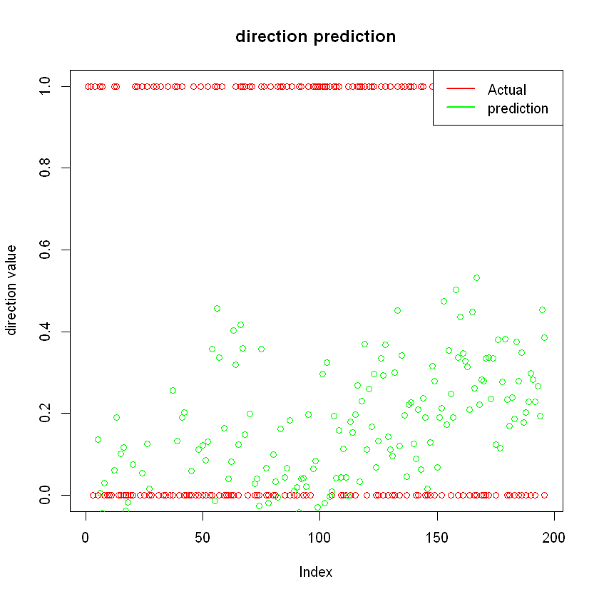

```r
par(mfrow =c(1,1))
plot(test_data$tar, type ="p", col="red", main = "direction prediction", ylab = "direction value")
points(predicted_data, type="p",col = "green")
legend("topright", inset = 0.0005, c("Actual", "prediction"), lwd=2, lty=c(1,1,1,1,2), col = c("red", "green"))
```

```r
predicted_data <- ifelse(probg > 0.5, 1, 0)
```

```r
table_mat <- table(test_data$tar, predicted_data)
table_mat
```

```
   predicted_data
     0  1
  0 31 66
  1 22 77
```

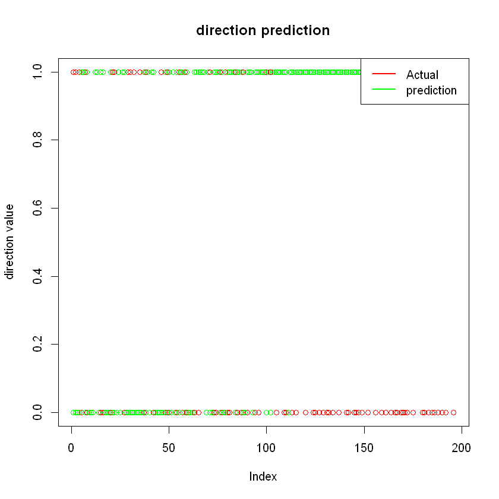

```r
par(mfrow =c(1,1))
plot(test_data$tar, type ="p", col="red", main = "direction prediction", ylab = "direction value")
points(predicted_data, type="p",col = "green")
legend("topright", inset = 0.0005, c("Actual", "prediction"), lwd=2, lty=c(1,1,1,1,2), col = c("red", "green"))
```

```r
mean(predicted_data == test_data$tar)
```

0.551020408163265

```r
f <- data.frame(predicted_data)
f$target <- test_data$tar
```

```r
rownames(f) <- NULL
summary(f)
```

```
 predicted_data       target
 Min.   :0.0000   Min.   :0.0000
 1st Qu.:0.0000   1st Qu.:0.0000
 Median :1.0000   Median :1.0000
 Mean   :0.7296   Mean   :0.5051
 3rd Qu.:1.0000   3rd Qu.:1.0000
 Max.   :1.0000   Max.   :1.0000
```

# Evaluation metrics

```r
f$predicted_data <- as.factor(f$predicted_data)
f$target <- as.factor(f$target)
f
```

| predicted_data | target |
| --- | --- |
| 0 | 1 |
| 0 | 1 |
| 0 | 0 |
| 0 | 1 |
| 1 | 0 |
| 1 | 1 |
| 0 | 1 |
| 1 | 0 |
| 0 | 0 |
| 0 | 0 |
| 0 | 0 |
| 1 | 1 |
| 1 | 1 |
| 0 | 0 |
| 1 | 0 |
| 1 | 0 |
| 0 | 0 |
| 0 | 0 |
| 0 | 0 |
| 1 | 0 |
| 0 | 1 |
| 0 | 1 |
| 0 | 0 |
| 1 | 1 |
| 0 | 0 |
| 1 | 1 |
| 1 | 0 |
| 0 | 0 |
| 0 | 1 |
| 0 | 1 |
| ... | ... |
| 1 | 0 |
| 1 | 1 |
| 1 | 0 |
| 1 | 0 |
| 1 | 0 |
| 1 | 0 |
| 1 | 1 |
| 1 | 1 |
| 1 | 0 |
| 1 | 1 |
| 1 | 1 |
| 1 | 1 |
| 1 | 1 |
| 1 | 0 |
| 1 | 0 |
| 1 | 1 |
| 1 | 0 |
| 1 | 1 |
| 1 | 0 |
| 1 | 0 |
| 1 | 1 |
| 1 | 0 |
| 1 | 1 |
| 1 | 0 |
| 1 | 1 |
| 1 | 0 |
| 1 | 1 |
| 1 | 1 |
| 1 | 1 |
| 1 | 0 |

```r
library(readxl)
library(caret)
library(e1071)
```

```r
confusionMatrix(f$predicted_data,reference = f$target)
```

```
Confusion Matrix and Statistics

          Reference
Prediction  0  1
         0 31 22
         1 66 77

               Accuracy : 0.551
                 95% CI : (0.4785, 0.622)
    No Information Rate : 0.5051
    P-Value [Acc > NIR] : 0.1122

                  Kappa : 0.0978

 Mcnemar's Test P-Value : 4.566e-06

            Sensitivity : 0.3196
            Specificity : 0.7778
         Pos Pred Value : 0.5849
         Neg Pred Value : 0.5385
             Prevalence : 0.4949
         Detection Rate : 0.1582
   Detection Prevalence : 0.2704
      Balanced Accuracy : 0.5487

       'Positive' Class : 0
```

```r
library(Metrics)
```

```r
AUC <- Metrics::auc(f$target,f$predicted_data)
AUC
```

0.548682703321879

```r
library(ROCR)
```

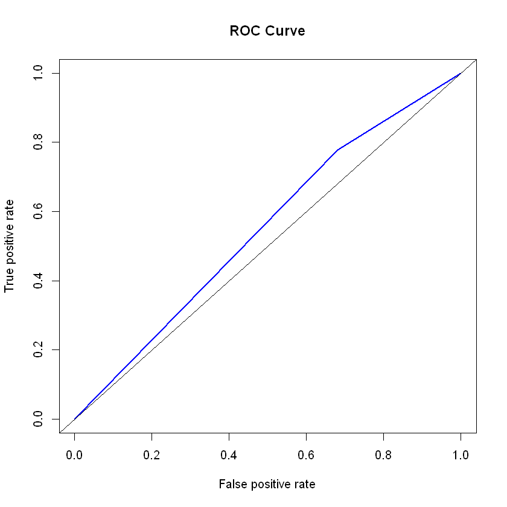

```r
library(ROCR)
prediction <- prediction(predictions =as.numeric(f$predicted_data),labels = as.numeric(f$target))
perf <- performance(prediction,"tpr","fpr")
plot(perf,lwd=2,col='blue',main="ROC Curve")
abline(a=0, b= 1)
```

```r
cost_perf = performance(prediction, "cost")
prediction@cutoffs[[1]][which.min(cost_perf@y.values[[1]])]
```

2

```r
library(pROC)
```

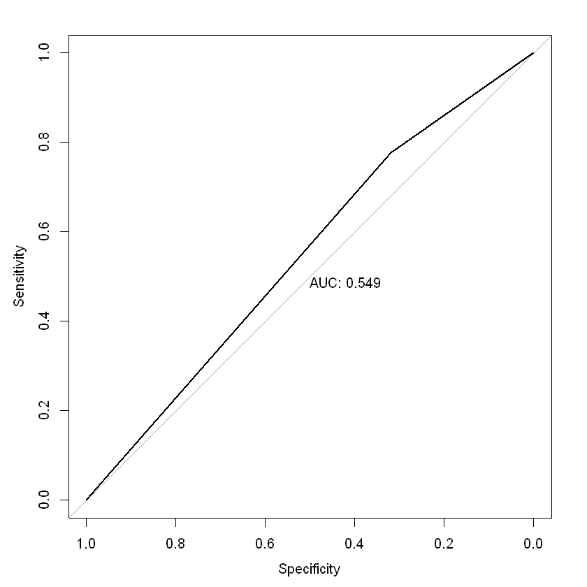

```r
res.roc <- roc(f$target, as.numeric(f$predicted_data))
plot.roc(res.roc, print.auc = TRUE)
```

# Question # 04

```r
library(caret)
```

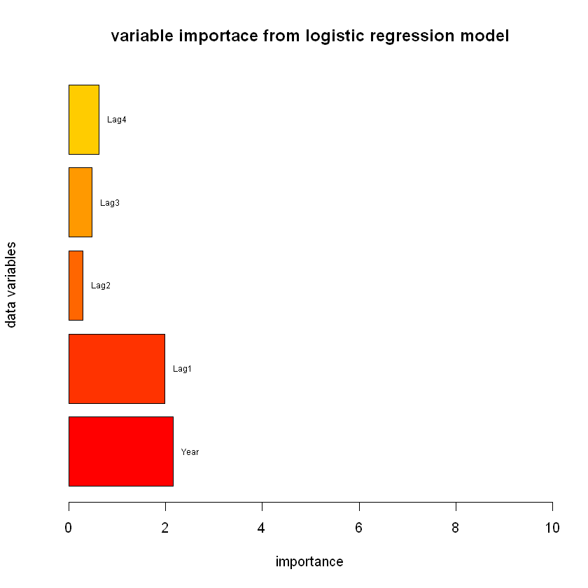

```r
imp <- varImp(myglm)
bp <- barplot(imp[,1], xlab="importance", ylab = "data variables",
             main = "variable importace from logistic regression model",
             col = heat.colors(7), horiz = TRUE, xlim = range(0,10))
a <- imp[,1]
names <- rownames(imp)
text(a, bp, names, pos=4, cex=0.6)
```

### Good Job! You are done with the section!

## Section 4: Machine Learning: Decision Trees and Random Forests

## Question 1

**Construct a decision tree for the following dataset:**

1. Your task is to predict whether the sales will be High or Low.
2. You need to transform the Sale variable into binary variable: For sales less than 7.5, assign a value of Low and High otherwise. You will also need to transform ShelveLoc, Urban and US variables into binary variables.
3. Generate a decision tree and plot the diagram for the tree and plot predicted vs. actual results.
4. Attempt a random forest regression on the same dataset. Which model produces better results?

```r
require('ISLR')
head(Carseats)
```

| Sales | CompPrice | Income | Advertising | Population | Price | ShelveLoc | Age | Education | Urban | US |
| --- | --- | --- | --- | --- | --- | --- | --- | --- | --- | --- |
| 9.50 | 138 | 73 | 11 | 276 | 120 | Bad | 42 | 17 | Yes | Yes |
| 11.22 | 111 | 48 | 16 | 260 | 83 | Good | 65 | 10 | Yes | Yes |
| 10.06 | 113 | 35 | 10 | 269 | 80 | Medium | 59 | 12 | Yes | Yes |
| 7.40 | 117 | 100 | 4 | 466 | 97 | Medium | 55 | 14 | Yes | Yes |
| 4.15 | 141 | 64 | 3 | 340 | 128 | Bad | 38 | 13 | Yes | No |
| 10.81 | 124 | 113 | 13 | 501 | 72 | Bad | 78 | 16 | No | Yes |

```r
df <- Carseats
head(df)
```

| Sales | CompPrice | Income | Advertising | Population | Price | ShelveLoc | Age | Education | Urban | US |
| --- | --- | --- | --- | --- | --- | --- | --- | --- | --- | --- |
| 9.50 | 138 | 73 | 11 | 276 | 120 | Bad | 42 | 17 | Yes | Yes |
| 11.22 | 111 | 48 | 16 | 260 | 83 | Good | 65 | 10 | Yes | Yes |
| 10.06 | 113 | 35 | 10 | 269 | 80 | Medium | 59 | 12 | Yes | Yes |
| 7.40 | 117 | 100 | 4 | 466 | 97 | Medium | 55 | 14 | Yes | Yes |
| 4.15 | 141 | 64 | 3 | 340 | 128 | Bad | 38 | 13 | Yes | No |
| 10.81 | 124 | 113 | 13 | 501 | 72 | Bad | 78 | 16 | No | Yes |

```r
library(dplyr)
glimpse(df)
```

```
Observations: 400
Variables: 11
$ Sales       <dbl> 9.50, 11.22, 10.06, 7.40, 4.15, 10.81, 6.63, 11.85, 6.5...
$ CompPrice   <dbl> 138, 111, 113, 117, 141, 124, 115, 136, 132, 132, 121, ...
$ Income      <dbl> 73, 48, 35, 100, 64, 113, 105, 81, 110, 113, 78, 94, 35...
$ Advertising <dbl> 11, 16, 10, 4, 3, 13, 0, 15, 0, 0, 9, 4, 2, 11, 11, 5, ...
$ Population  <dbl> 276, 260, 269, 466, 340, 501, 45, 425, 108, 131, 150, 5...
$ Price       <dbl> 120, 83, 80, 97, 128, 72, 108, 120, 124, 124, 100, 94, ...
$ ShelveLoc   <fct> Bad, Good, Medium, Medium, Bad, Bad, Medium, Good, Medi...
$ Age         <dbl> 42, 65, 59, 55, 38, 78, 71, 67, 76, 76, 26, 50, 62, 53,...
$ Education   <dbl> 17, 10, 12, 14, 13, 16, 15, 10, 10, 17, 10, 13, 18, 18,...
$ Urban       <fct> Yes, Yes, Yes, Yes, Yes, No, Yes, Yes, No, No, No, Yes,...
$ US          <fct> Yes, Yes, Yes, Yes, No, Yes, No, Yes, No, Yes, Yes, Yes...
```

```r
str(df)
```

```
'data.frame':	400 obs. of  11 variables:
 $ Sales      : num  9.5 11.22 10.06 7.4 4.15 ...
 $ CompPrice  : num  138 111 113 117 141 124 115 136 132 132 ...
 $ Income     : num  73 48 35 100 64 113 105 81 110 113 ...
 $ Advertising: num  11 16 10 4 3 13 0 15 0 0 ...
 $ Population : num  276 260 269 466 340 501 45 425 108 131 ...
 $ Price      : num  120 83 80 97 128 72 108 120 124 124 ...
 $ ShelveLoc  : Factor w/ 3 levels "Bad","Good","Medium": 1 2 3 3 1 1 3 2 3 3 ...
 $ Age        : num  42 65 59 55 38 78 71 67 76 76 ...
 $ Education  : num  17 10 12 14 13 16 15 10 10 17 ...
 $ Urban      : Factor w/ 2 levels "No","Yes": 2 2 2 2 2 1 2 2 1 1 ...
 $ US         : Factor w/ 2 levels "No","Yes": 2 2 2 2 1 2 1 2 1 2 ...
```

```r
summary(df)
```

```
     Sales          CompPrice       Income        Advertising
 Min.   : 0.000   Min.   : 77   Min.   : 21.00   Min.   : 0.000
 1st Qu.: 5.390   1st Qu.:115   1st Qu.: 42.75   1st Qu.: 0.000
 Median : 7.490   Median :125   Median : 69.00   Median : 5.000
 Mean   : 7.496   Mean   :125   Mean   : 68.66   Mean   : 6.635
 3rd Qu.: 9.320   3rd Qu.:135   3rd Qu.: 91.00   3rd Qu.:12.000
 Max.   :16.270   Max.   :175   Max.   :120.00   Max.   :29.000
   Population        Price        ShelveLoc        Age          Education
 Min.   : 10.0   Min.   : 24.0   Bad   : 96   Min.   :25.00   Min.   :10.0
 1st Qu.:139.0   1st Qu.:100.0   Good  : 85   1st Qu.:39.75   1st Qu.:12.0
 Median :272.0   Median :117.0   Medium:219   Median :54.50   Median :14.0
 Mean   :264.8   Mean   :115.8                Mean   :53.32   Mean   :13.9
 3rd Qu.:398.5   3rd Qu.:131.0                3rd Qu.:66.00   3rd Qu.:16.0
 Max.   :509.0   Max.   :191.0                Max.   :80.00   Max.   :18.0
 Urban       US
 No :118   No :142
 Yes:282   Yes:258
```

# Question # 02

```r
df$target <- ifelse(df$Sales >= 7.5, 1, 0)
```

```r
table(df$target)
```

```
  0   1
201 199
```

```r
table(df$Urban)
```

```
 No Yes
118 282
```

```r
table(df$US)
```

```
 No Yes
142 258
```

```r
table(df$ShelveLoc)
```

```
   Bad   Good Medium
    96     85    219
```

```r
df$target <- ifelse(df$Sales >= 7.5, 1, 0)
df$target <- as.integer(df$target)
df$Urban <- ifelse(df$Urban == 'Yes', 1, 0)
df$Urban <- as.integer(df$Urban)
df$US <- ifelse(df$US =='Yes', 1, 0)
df$US <- as.integer(df$US)
```

```r
df$ShelveLoc <- factor(df$ShelveLoc, levels=c('Good', 'Medium','Bad'), labels=c(2, 1, 0))
df$ShelveLoc <- as.numeric(df$ShelveLoc)
df$ShelveLoc[df$ShelveLoc == 1] <- 0
df$ShelveLoc[df$ShelveLoc == 2] <- 1
df$ShelveLoc[df$ShelveLoc == 3] <- 2
df$ShelveLoc <- as.integer(df$ShelveLoc)
```

```r
df$ShelveLoc <- as.factor(df$ShelveLoc)
df$target <- as.factor(df$target)
df$Urban <- as.factor(df$Urban)
df$US <- as.factor(df$US)
```

```r
head(df)
```

| Sales | CompPrice | Income | Advertising | Population | Price | ShelveLoc | Age | Education | Urban | US | target |
| --- | --- | --- | --- | --- | --- | --- | --- | --- | --- | --- | --- |
| 9.50 | 138 | 73 | 11 | 276 | 120 | 2 | 42 | 17 | 1 | 1 | 1 |
| 11.22 | 111 | 48 | 16 | 260 | 83 | 0 | 65 | 10 | 1 | 1 | 1 |
| 10.06 | 113 | 35 | 10 | 269 | 80 | 1 | 59 | 12 | 1 | 1 | 1 |
| 7.40 | 117 | 100 | 4 | 466 | 97 | 1 | 55 | 14 | 1 | 1 | 0 |
| 4.15 | 141 | 64 | 3 | 340 | 128 | 2 | 38 | 13 | 1 | 0 | 0 |
| 10.81 | 124 | 113 | 13 | 501 | 72 | 2 | 78 | 16 | 0 | 1 | 1 |

```r
str(df)
```

```
'data.frame':	400 obs. of  12 variables:
 $ Sales      : num  9.5 11.22 10.06 7.4 4.15 ...
 $ CompPrice  : num  138 111 113 117 141 124 115 136 132 132 ...
 $ Income     : num  73 48 35 100 64 113 105 81 110 113 ...
 $ Advertising: num  11 16 10 4 3 13 0 15 0 0 ...
 $ Population : num  276 260 269 466 340 501 45 425 108 131 ...
 $ Price      : num  120 83 80 97 128 72 108 120 124 124 ...
 $ ShelveLoc  : Factor w/ 3 levels "0","1","2": 3 1 2 2 3 3 2 1 2 2 ...
 $ Age        : num  42 65 59 55 38 78 71 67 76 76 ...
 $ Education  : num  17 10 12 14 13 16 15 10 10 17 ...
 $ Urban      : Factor w/ 2 levels "0","1": 2 2 2 2 2 1 2 2 1 1 ...
 $ US         : Factor w/ 2 levels "0","1": 2 2 2 2 1 2 1 2 1 2 ...
 $ target     : Factor w/ 2 levels "0","1": 2 2 2 1 1 2 1 2 1 1 ...
```

```r
nrow(df[is.na(df)])
```

[output not shown]

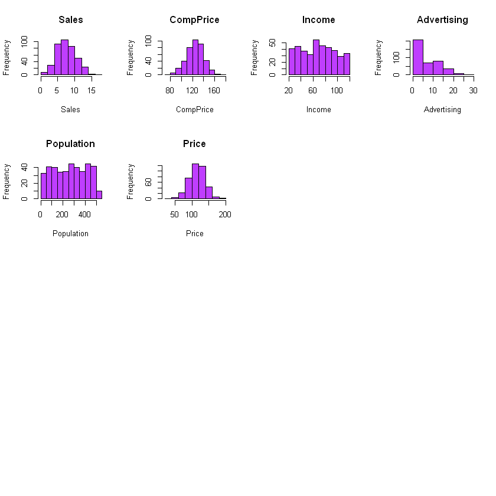

```r
par(mfrow = c(4,4))
for(i in 1:12){
    hist(df[,i], main = colnames(df)[i], xlab = colnames(df)[i], col = 'darkorchid1')
}
```

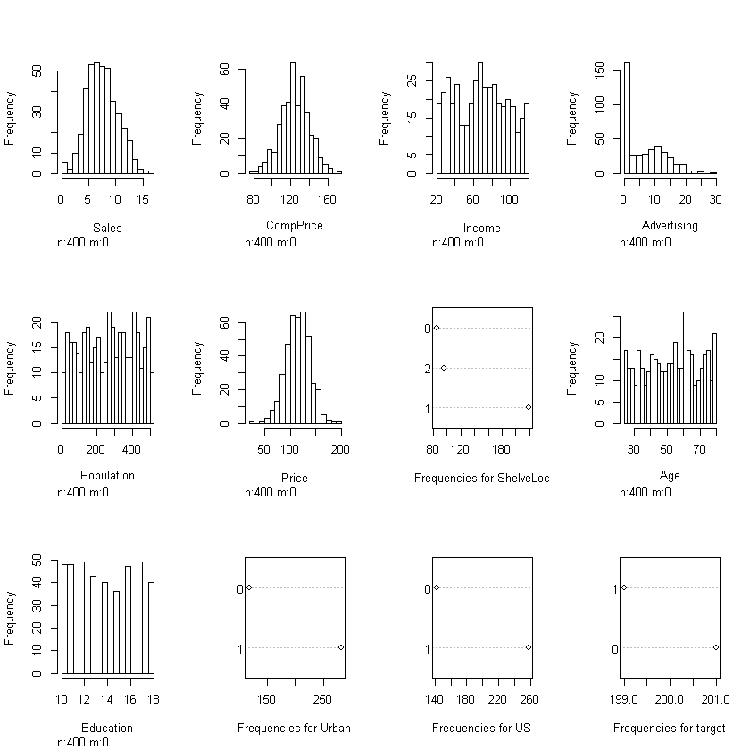

```r
library(Hmisc)
hist.data.frame(df)
```

```r
library(party)
library(caret)
```

```r
indexes = createDataPartition(df$target, p=.9, list=F)
train = df[indexes,]
test = df[-indexes,]
```

```r
head(train)
```

| Sales | CompPrice | Income | Advertising | Population | Price | ShelveLoc | Age | Education | Urban | US | target |
| --- | --- | --- | --- | --- | --- | --- | --- | --- | --- | --- | --- |
| 9.50 | 138 | 73 | 11 | 276 | 120 | 2 | 42 | 17 | 1 | 1 | 1 |
| 11.22 | 111 | 48 | 16 | 260 | 83 | 0 | 65 | 10 | 1 | 1 | 1 |
| 10.06 | 113 | 35 | 10 | 269 | 80 | 1 | 59 | 12 | 1 | 1 | 1 |
| 7.40 | 117 | 100 | 4 | 466 | 97 | 1 | 55 | 14 | 1 | 1 | 0 |
| 4.15 | 141 | 64 | 3 | 340 | 128 | 2 | 38 | 13 | 1 | 0 | 0 |
| 10.81 | 124 | 113 | 13 | 501 | 72 | 2 | 78 | 16 | 0 | 1 | 1 |

```r
train <- subset(train, select = - c(Sales))
test <- subset(test, select = - c(Sales))
```

```r
head(train)
```

| CompPrice | Income | Advertising | Population | Price | ShelveLoc | Age | Education | Urban | US | target |
| --- | --- | --- | --- | --- | --- | --- | --- | --- | --- | --- |
| 138 | 73 | 11 | 276 | 120 | 2 | 42 | 17 | 1 | 1 | 1 |
| 111 | 48 | 16 | 260 | 83 | 0 | 65 | 10 | 1 | 1 | 1 |
| 113 | 35 | 10 | 269 | 80 | 1 | 59 | 12 | 1 | 1 | 1 |
| 117 | 100 | 4 | 466 | 97 | 1 | 55 | 14 | 1 | 1 | 0 |
| 141 | 64 | 3 | 340 | 128 | 2 | 38 | 13 | 1 | 0 | 0 |
| 124 | 113 | 13 | 501 | 72 | 2 | 78 | 16 | 0 | 1 | 1 |

# Question # 03

```r
library(rpart)
library(rpart.plot)
```

```r
fit <- rpart(target~., data = train, method = 'class')
```

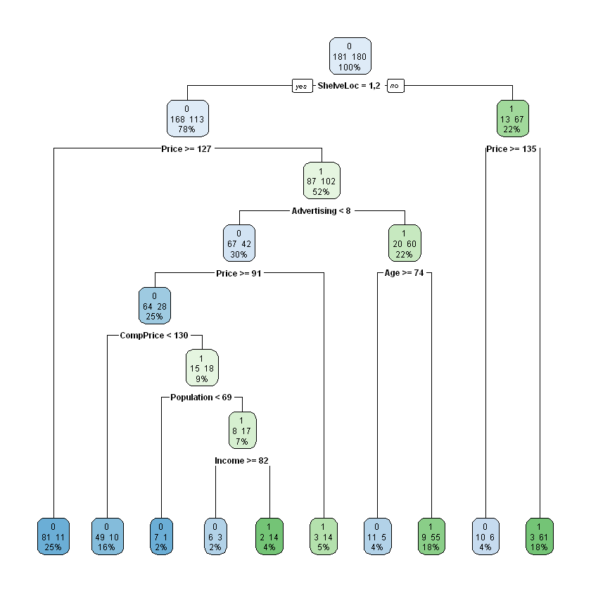

```r
rpart.plot(fit, extra = 101)
```

```r
pred <- predict(fit, test, type = 'class')
head(pred)
```

**11**

1

**18**

1

**32**

0

**39**

0

**41**

0

**60**

0

**Levels**:**

1. '0'

2. '1'

```r
table_mat <- table(test$target, pred)
table_mat
```

```
   pred
     0  1
  0 14  6
  1  9 10
```

```r
accuracy_Test <- sum(diag(table_mat)) / sum(table_mat)
accuracy_Test
```

0.615384615384615

# Evalution method

```r
confusionMatrix(pred,reference = test$target)
```

```
Confusion Matrix and Statistics

          Reference
Prediction  0  1
         0 14  9
         1  6 10

               Accuracy : 0.6154
                 95% CI : (0.4462, 0.7664)
    No Information Rate : 0.5128
    P-Value [Acc > NIR] : 0.1309

                  Kappa : 0.2272

 Mcnemar's Test P-Value : 0.6056

            Sensitivity : 0.7000
            Specificity : 0.5263
         Pos Pred Value : 0.6087
         Neg Pred Value : 0.6250
             Prevalence : 0.5128
         Detection Rate : 0.3590
   Detection Prevalence : 0.5897
      Balanced Accuracy : 0.6132

       'Positive' Class : 0
```

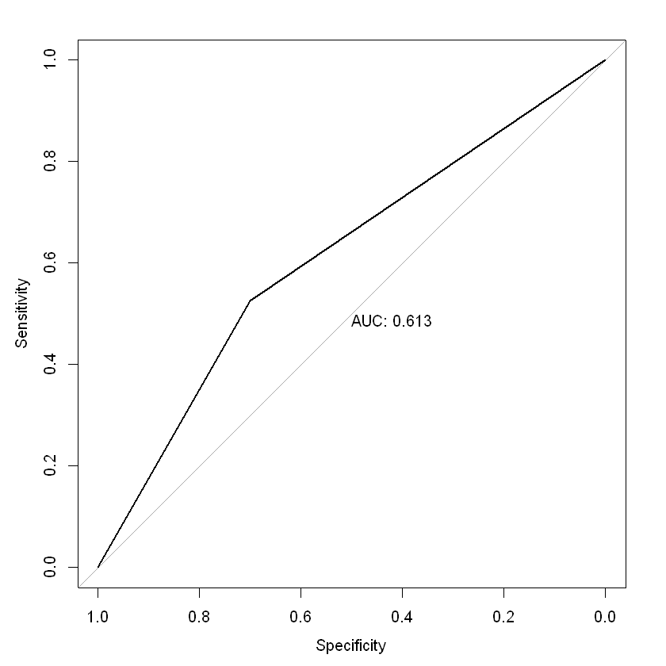

```r
library(pROC)
res.roc <- roc(test$target, as.numeric(pred))
plot.roc(res.roc, print.auc = TRUE)
```

# Question # 04

```r
library(randomForest)
?randomForest
```

```r
rand <- randomForest(target ~ ., data =train, ntree =50)
```

```r
print(rand)
```

```
Call:
 randomForest(formula = target ~ ., data = train, ntree = 50)
               Type of random forest: classification
                     Number of trees: 50
No. of variables tried at each split: 3

        OOB estimate of  error rate: 18.84%
Confusion matrix:
    0   1 class.error
0 148  33   0.1823204
1  35 145   0.1944444
```

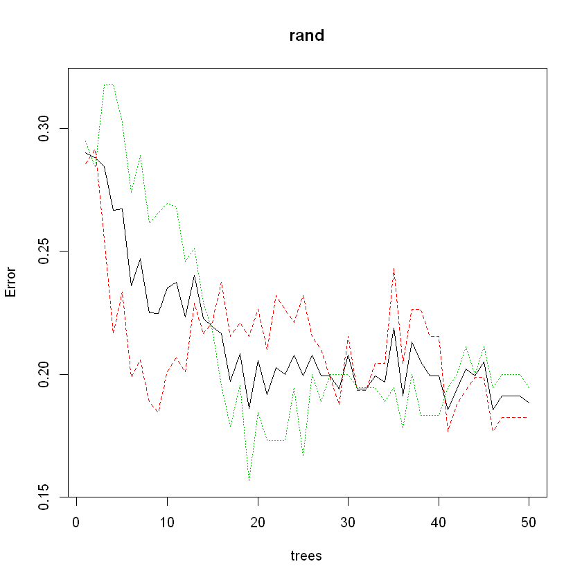

```r
plot(rand)
```

```r
importance(rand)
```

|  | MeanDecreaseGini |
| --- | --- |
| CompPrice | 20.626054 |
| Income | 18.664653 |
| Advertising | 19.184340 |
| Population | 13.734108 |
| Price | 49.689094 |
| ShelveLoc | 22.735667 |
| Age | 23.044164 |
| Education | 8.346772 |
| Urban | 2.031918 |
| US | 1.473795 |

```r
prediction <- predict(rand, newdata = test)
```

```r
table(prediction, test$target)
```

```
prediction  0  1
         0 16  5
         1  4 14
```

```r
model <- randomForest(target ~ . , data = train, ntree = 37, mtry = 5)
```

```r
model
```

```
Call:
 randomForest(formula = target ~ ., data = train, ntree = 37,      mtry = 5)
               Type of random forest: classification
                     Number of trees: 37
No. of variables tried at each split: 5

        OOB estimate of  error rate: 19.67%
Confusion matrix:
    0   1 class.error
0 150  31   0.1712707
1  40 140   0.2222222
```

```r
model$confusion
```

|  | 0 | 1 | class.error |
| --- | --- | --- | --- |
| 0 | 150 | 31 | 0.1712707 |
| 1 | 40 | 140 | 0.2222222 |

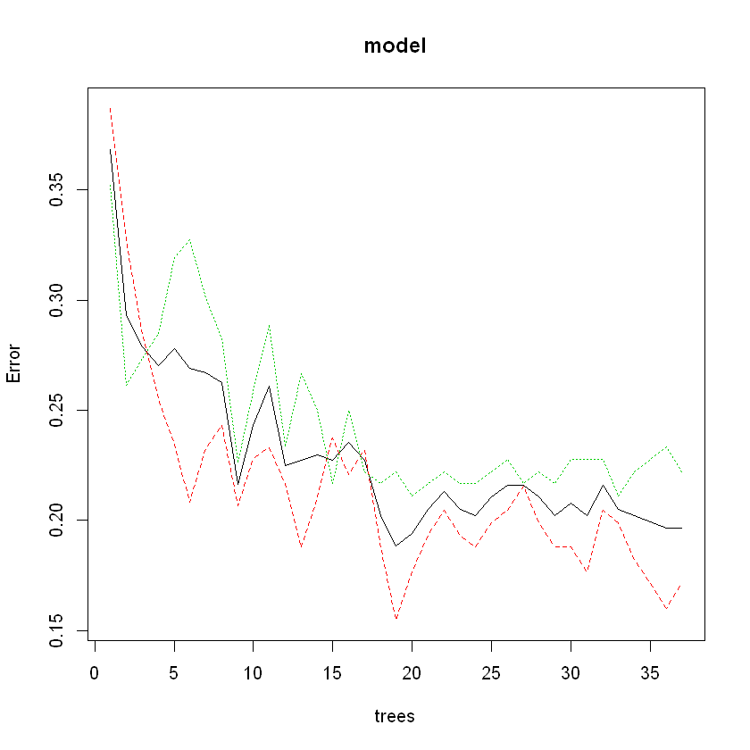

```r
plot(model)
```

```r
importance(model)
```

|  | MeanDecreaseGini |
| --- | --- |
| CompPrice | 21.969606 |
| Income | 15.450836 |
| Advertising | 18.682278 |
| Population | 13.543045 |
| Price | 52.969086 |
| ShelveLoc | 26.961253 |
| Age | 20.986774 |
| Education | 6.571320 |
| Urban | 1.551382 |
| US | 1.266205 |

```r
prediction <- predict(model, newdata = test)
test$prediction <- prediction
```

```r
table(test$prediction, test$target)
head(prediction)
```

```
     0  1
  0 15  6
  1  5 13
```

**11**

1

**18**

1

**32**

0

**39**

0

**41**

0

**60**

0

**Levels**:**

1. '0'

2. '1'

```r
# Evaluation method
```

```r
confusionMatrix(test$prediction,reference = test$target)
```

```
Confusion Matrix and Statistics

          Reference
Prediction  0  1
         0 15  6
         1  5 13

               Accuracy : 0.7179
                 95% CI : (0.5513, 0.85)
    No Information Rate : 0.5128
    P-Value [Acc > NIR] : 0.007431

                  Kappa : 0.4348

 Mcnemar's Test P-Value : 1.000000

            Sensitivity : 0.7500
            Specificity : 0.6842
         Pos Pred Value : 0.7143
         Neg Pred Value : 0.7222
             Prevalence : 0.5128
         Detection Rate : 0.3846
   Detection Prevalence : 0.5385
      Balanced Accuracy : 0.7171

       'Positive' Class : 0
```

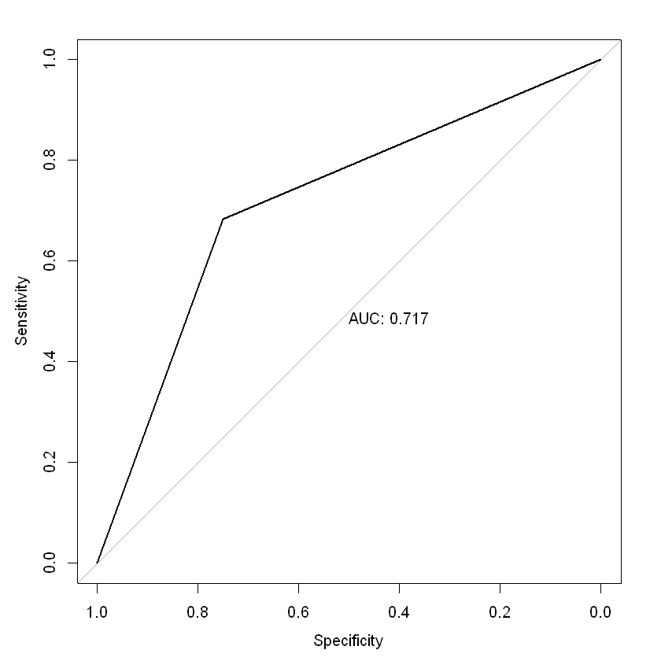

```r
library(pROC)
res.roc <- roc(test$target, as.numeric(test$prediction))
plot.roc(res.roc, print.auc = TRUE)
```

```r
AUC <- Metrics::auc(test$target,test$prediction)
AUC
```

0.717105263157895

### Good Job! You are done with the section!

## Section 5: Neural Networks

## Question 1

**Construct a neural network for the same dataset:**

1. Your task is to predict whether the sales will be High or Low.
2. Perform necessary data transformations as required.
3. Generate neural network with 3 layers and 2,3,4 nodes respectively.
4. Plot the nn.

```r
#install.packages('neuralnet')
library(neuralnet)
```

```r
head(df)
```

| Sales | CompPrice | Income | Advertising | Population | Price | ShelveLoc | Age | Education | Urban | US | target |
| --- | --- | --- | --- | --- | --- | --- | --- | --- | --- | --- | --- |
| 9.50 | 138 | 73 | 11 | 276 | 120 | 2 | 42 | 17 | 1 | 1 | 1 |
| 11.22 | 111 | 48 | 16 | 260 | 83 | 0 | 65 | 10 | 1 | 1 | 1 |
| 10.06 | 113 | 35 | 10 | 269 | 80 | 1 | 59 | 12 | 1 | 1 | 1 |
| 7.40 | 117 | 100 | 4 | 466 | 97 | 1 | 55 | 14 | 1 | 1 | 0 |
| 4.15 | 141 | 64 | 3 | 340 | 128 | 2 | 38 | 13 | 1 | 0 | 0 |
| 10.81 | 124 | 113 | 13 | 501 | 72 | 2 | 78 | 16 | 0 | 1 | 1 |

```r
head(df)
```

| Sales | CompPrice | Income | Advertising | Population | Price | ShelveLoc | Age | Education | Urban | US | target |
| --- | --- | --- | --- | --- | --- | --- | --- | --- | --- | --- | --- |
| 9.50 | 138 | 73 | 11 | 276 | 120 | 2 | 42 | 17 | 1 | 1 | 1 |
| 11.22 | 111 | 48 | 16 | 260 | 83 | 0 | 65 | 10 | 1 | 1 | 1 |
| 10.06 | 113 | 35 | 10 | 269 | 80 | 1 | 59 | 12 | 1 | 1 | 1 |
| 7.40 | 117 | 100 | 4 | 466 | 97 | 1 | 55 | 14 | 1 | 1 | 0 |
| 4.15 | 141 | 64 | 3 | 340 | 128 | 2 | 38 | 13 | 1 | 0 | 0 |
| 10.81 | 124 | 113 | 13 | 501 | 72 | 2 | 78 | 16 | 0 | 1 | 1 |

```r
dfn <- df[2:6]
dfn$Age <- df$Age
dfn$Education <- df$Education
dfn$ShelveLoc <- df$ShelveLoc
dfn$Urban <- df$Urban
dfn$US <- df$US
dfn$target <- df$target
head(dfn)
```

| CompPrice | Income | Advertising | Population | Price | Age | Education | ShelveLoc | Urban | US | target |
| --- | --- | --- | --- | --- | --- | --- | --- | --- | --- | --- |
| 138 | 73 | 11 | 276 | 120 | 42 | 17 | 2 | 1 | 1 | 1 |
| 111 | 48 | 16 | 260 | 83 | 65 | 10 | 0 | 1 | 1 | 1 |
| 113 | 35 | 10 | 269 | 80 | 59 | 12 | 1 | 1 | 1 | 1 |
| 117 | 100 | 4 | 466 | 97 | 55 | 14 | 1 | 1 | 1 | 0 |
| 141 | 64 | 3 | 340 | 128 | 38 | 13 | 2 | 1 | 0 | 0 |
| 124 | 113 | 13 | 501 | 72 | 78 | 16 | 2 | 0 | 1 | 1 |

```r
min_max_norm <- function(x) {
    (x - min(x)) / (max(x) - min(x))
  }
```

```r
df_norm <- as.data.frame(lapply(dfn[,1:7], min_max_norm))

head(df_norm)
```

| CompPrice | Income | Advertising | Population | Price | Age | Education |
| --- | --- | --- | --- | --- | --- | --- |
| 0.6224490 | 0.5252525 | 0.3793103 | 0.5330661 | 0.5748503 | 0.3090909 | 0.875 |
| 0.3469388 | 0.2727273 | 0.5517241 | 0.5010020 | 0.3532934 | 0.7272727 | 0.000 |
| 0.3673469 | 0.1414141 | 0.3448276 | 0.5190381 | 0.3353293 | 0.6181818 | 0.250 |
| 0.4081633 | 0.7979798 | 0.1379310 | 0.9138277 | 0.4371257 | 0.5454545 | 0.500 |
| 0.6530612 | 0.4343434 | 0.1034483 | 0.6613226 | 0.6227545 | 0.2363636 | 0.375 |
| 0.4795918 | 0.9292929 | 0.4482759 | 0.9839679 | 0.2874251 | 0.9636364 | 0.750 |

```r
dfb <- dfn[,8:11]
head(dfb)
```

| ShelveLoc | Urban | US | target |
| --- | --- | --- | --- |
| 2 | 1 | 1 | 1 |
| 0 | 1 | 1 | 1 |
| 1 | 1 | 1 | 1 |
| 1 | 1 | 1 | 0 |
| 2 | 1 | 0 | 0 |
| 2 | 0 | 1 | 1 |

```r
df_norm <- cbind(df_norm,dfb)
head(df_norm)
```

| CompPrice | Income | Advertising | Population | Price | Age | Education | ShelveLoc | Urban | US | target |
| --- | --- | --- | --- | --- | --- | --- | --- | --- | --- | --- |
| 0.6224490 | 0.5252525 | 0.3793103 | 0.5330661 | 0.5748503 | 0.3090909 | 0.875 | 2 | 1 | 1 | 1 |
| 0.3469388 | 0.2727273 | 0.5517241 | 0.5010020 | 0.3532934 | 0.7272727 | 0.000 | 0 | 1 | 1 | 1 |
| 0.3673469 | 0.1414141 | 0.3448276 | 0.5190381 | 0.3353293 | 0.6181818 | 0.250 | 1 | 1 | 1 | 1 |
| 0.4081633 | 0.7979798 | 0.1379310 | 0.9138277 | 0.4371257 | 0.5454545 | 0.500 | 1 | 1 | 1 | 0 |
| 0.6530612 | 0.4343434 | 0.1034483 | 0.6613226 | 0.6227545 | 0.2363636 | 0.375 | 2 | 1 | 0 | 0 |
| 0.4795918 | 0.9292929 | 0.4482759 | 0.9839679 | 0.2874251 | 0.9636364 | 0.750 | 2 | 0 | 1 | 1 |

```r
df_norm$ShelveLoc <- as.numeric(df_norm$ShelveLoc)
df_norm$Urban <- as.numeric(df_norm$Urban)
df_norm$US <- as.numeric(df_norm$US)
df_norm$target <- as.numeric(df_norm$target)
```

```r
df_norm["target"][df_norm["target"] == 1] <- 0
df_norm["target"][df_norm["target"] == 2] <- 1
```

```r
head(df_norm)
str(df_norm)
```

| CompPrice | Income | Advertising | Population | Price | Age | Education | ShelveLoc | Urban | US | target |
| --- | --- | --- | --- | --- | --- | --- | --- | --- | --- | --- |
| 0.6224490 | 0.5252525 | 0.3793103 | 0.5330661 | 0.5748503 | 0.3090909 | 0.875 | 3 | 2 | 2 | 1 |
| 0.3469388 | 0.2727273 | 0.5517241 | 0.5010020 | 0.3532934 | 0.7272727 | 0.000 | 1 | 2 | 2 | 1 |
| 0.3673469 | 0.1414141 | 0.3448276 | 0.5190381 | 0.3353293 | 0.6181818 | 0.250 | 2 | 2 | 2 | 1 |
| 0.4081633 | 0.7979798 | 0.1379310 | 0.9138277 | 0.4371257 | 0.5454545 | 0.500 | 2 | 2 | 2 | 0 |
| 0.6530612 | 0.4343434 | 0.1034483 | 0.6613226 | 0.6227545 | 0.2363636 | 0.375 | 3 | 2 | 1 | 0 |
| 0.4795918 | 0.9292929 | 0.4482759 | 0.9839679 | 0.2874251 | 0.9636364 | 0.750 | 3 | 1 | 2 | 1 |

```
'data.frame':	400 obs. of  11 variables:
 $ CompPrice  : num  0.622 0.347 0.367 0.408 0.653 ...
 $ Income     : num  0.525 0.273 0.141 0.798 0.434 ...
 $ Advertising: num  0.379 0.552 0.345 0.138 0.103 ...
 $ Population : num  0.533 0.501 0.519 0.914 0.661 ...
 $ Price      : num  0.575 0.353 0.335 0.437 0.623 ...
 $ Age        : num  0.309 0.727 0.618 0.545 0.236 ...
 $ Education  : num  0.875 0 0.25 0.5 0.375 0.75 0.625 0 0 0.875 ...
 $ ShelveLoc  : num  3 1 2 2 3 3 2 1 2 2 ...
 $ Urban      : num  2 2 2 2 2 1 2 2 1 1 ...
 $ US         : num  2 2 2 2 1 2 1 2 1 2 ...
 $ target     : num  1 1 1 0 0 1 0 1 0 0 ...
```

```r
indexes_n = createDataPartition(df_norm$target, p=.9, list=F)
train_n = df_norm[indexes_n,]
test_n = df_norm[-indexes_n,]
head(train_n)
str(train_n)
```

| CompPrice | Income | Advertising | Population | Price | Age | Education | ShelveLoc | Urban | US | target |
| --- | --- | --- | --- | --- | --- | --- | --- | --- | --- | --- |
| 0.6224490 | 0.5252525 | 0.3793103 | 0.5330661 | 0.5748503 | 0.3090909 | 0.875 | 3 | 2 | 2 | 1 |
| 0.3469388 | 0.2727273 | 0.5517241 | 0.5010020 | 0.3532934 | 0.7272727 | 0.000 | 1 | 2 | 2 | 1 |
| 0.3673469 | 0.1414141 | 0.3448276 | 0.5190381 | 0.3353293 | 0.6181818 | 0.250 | 2 | 2 | 2 | 1 |
| 0.4081633 | 0.7979798 | 0.1379310 | 0.9138277 | 0.4371257 | 0.5454545 | 0.500 | 2 | 2 | 2 | 0 |
| 0.6530612 | 0.4343434 | 0.1034483 | 0.6613226 | 0.6227545 | 0.2363636 | 0.375 | 3 | 2 | 1 | 0 |
| 0.4795918 | 0.9292929 | 0.4482759 | 0.9839679 | 0.2874251 | 0.9636364 | 0.750 | 3 | 1 | 2 | 1 |

```
'data.frame':	360 obs. of  11 variables:
 $ CompPrice  : num  0.622 0.347 0.367 0.408 0.653 ...
 $ Income     : num  0.525 0.273 0.141 0.798 0.434 ...
 $ Advertising: num  0.379 0.552 0.345 0.138 0.103 ...
 $ Population : num  0.533 0.501 0.519 0.914 0.661 ...
 $ Price      : num  0.575 0.353 0.335 0.437 0.623 ...
 $ Age        : num  0.309 0.727 0.618 0.545 0.236 ...
 $ Education  : num  0.875 0 0.25 0.5 0.375 0.75 0.625 0 0 0.875 ...
 $ ShelveLoc  : num  3 1 2 2 3 3 2 1 2 2 ...
 $ Urban      : num  2 2 2 2 2 1 2 2 1 1 ...
 $ US         : num  2 2 2 2 1 2 1 2 1 2 ...
 $ target     : num  1 1 1 0 0 1 0 1 0 0 ...
```

```r
#?neuralnet
library(neuralnet)
```

```r
f <- as.formula("target~CompPrice+Income+Advertising++Population+Price+Age+Education+ShelveLoc+Urban+US")
nnf <- neuralnet(formula = f, data = train_n,
                 hidden = c(2,3,4),
                 linear.output = F,
                 act.fct = "logistic",
                 rep=1)
```

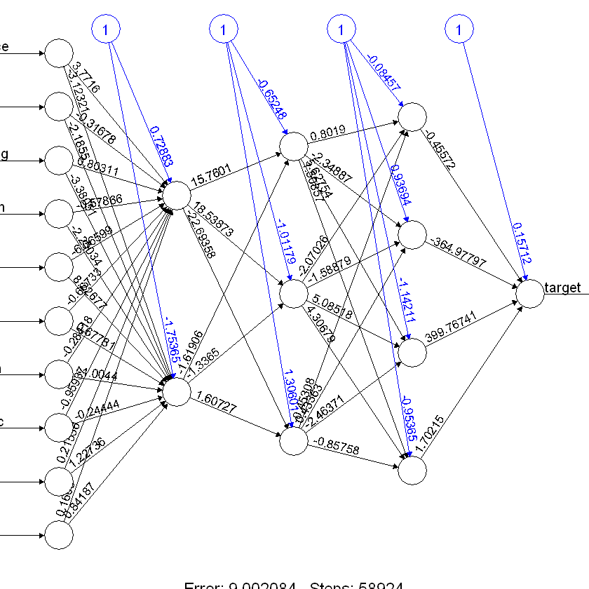

```r
plot(nnf, rep=1)
```

```r
head(test_n)
```

|  | CompPrice | Income | Advertising | Population | Price | Age | Education | ShelveLoc | Urban | US | target |
| --- | --- | --- | --- | --- | --- | --- | --- | --- | --- | --- | --- |
| 22 | 0.5816327 | 0.08080808 | 0.4137931 | 0.45891784 | 0.5089820 | 0.6727273 | 1.000 | 1 | 1 | 2 | 1 |
| 39 | 0.3265306 | 0.52525253 | 0.0000000 | 0.88977956 | 0.4670659 | 0.7272727 | 0.625 | 2 | 2 | 1 | 0 |
| 44 | 0.4693878 | 0.21212121 | 0.3793103 | 0.01202405 | 0.6586826 | 0.6181818 | 0.375 | 2 | 2 | 2 | 0 |
| 74 | 0.4183673 | 0.69696970 | 0.3448276 | 0.08817635 | 0.4790419 | 0.1090909 | 0.125 | 1 | 1 | 2 | 1 |
| 100 | 0.4489796 | 0.26262626 | 0.1034483 | 0.42084168 | 0.4970060 | 0.5636364 | 0.750 | 3 | 1 | 2 | 0 |
| 137 | 0.5510204 | 0.54545455 | 0.0000000 | 0.00000000 | 0.5748503 | 0.1090909 | 1.000 | 3 | 1 | 1 | 0 |

```r
Predict=compute(nnf,test_n)
head(Predict$net.result)
```

| 22 | 1.000000e+00 |
| --- | --- |
| 39 | 2.770359e-48 |
| 44 | 2.067427e-60 |
| 74 | 1.000000e+00 |
| 100 | 2.859112e-65 |
| 137 | 2.015496e-51 |

```r
prob <- Predict$net.result
pred <- ifelse(prob>0.5, 1, 0)
head(pred)
```

| 22 | 1 |
| --- | --- |
| 39 | 0 |
| 44 | 0 |
| 74 | 1 |
| 100 | 0 |
| 137 | 0 |

```r
rownames(pred) <- NULL
```

```r
test_n$pred <- pred
```

```r
table(test_n$pred, test_n$target)
```

```
     0  1
  0 21  1
  1  5 13
```

# Evaluation method

```r
confusionMatrix(as.factor(test_n$pred),reference = as.factor(test_n$target))
```

```
Confusion Matrix and Statistics

          Reference
Prediction  0  1
         0 21  1
         1  5 13

               Accuracy : 0.85
                 95% CI : (0.7016, 0.9429)
    No Information Rate : 0.65
    P-Value [Acc > NIR] : 0.004363

                  Kappa : 0.6907

 Mcnemar's Test P-Value : 0.220671

            Sensitivity : 0.8077
            Specificity : 0.9286
         Pos Pred Value : 0.9545
         Neg Pred Value : 0.7222
             Prevalence : 0.6500
         Detection Rate : 0.5250
   Detection Prevalence : 0.5500
      Balanced Accuracy : 0.8681

       'Positive' Class : 0
```

```
Warning message in roc.default(test_n$target, test_n$pred):
"Deprecated use a matrix as predictor. Unexpected results may be produced, please pass a numeric vector."Setting direction: controls < cases
```

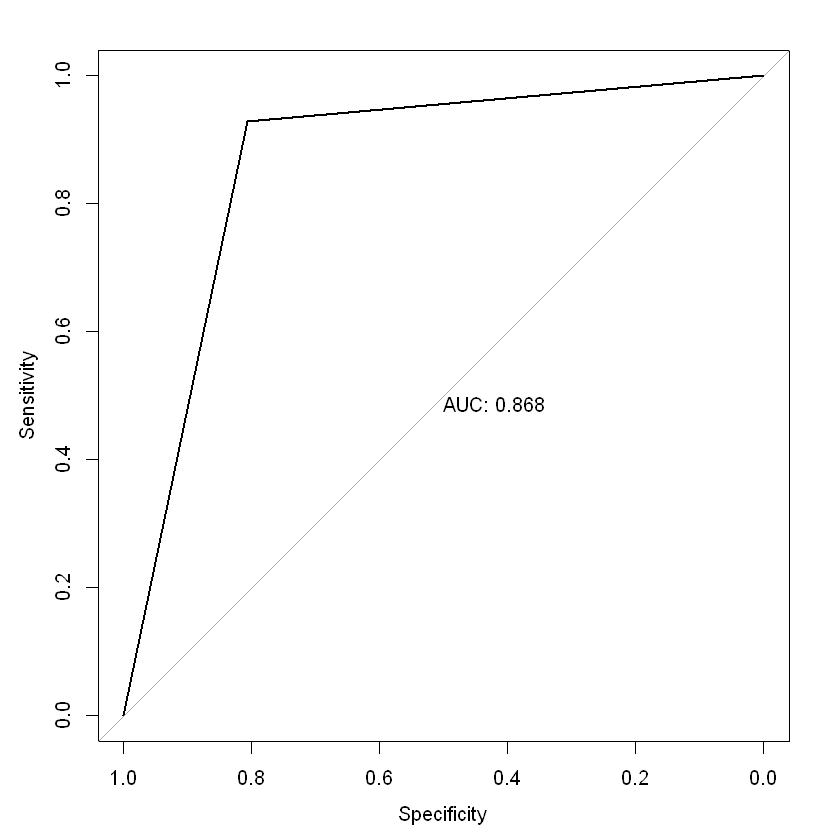

```r
library(pROC)
res.roc <- roc(test_n$target, test_n$pred)
plot.roc(res.roc, print.auc = TRUE)
```

### Good Job! You are done with the section!

## Section 6: Performance Evaluation

## Question 1

**For the above decision tree, logistic regression and neural network models:**

1. Construct a confusion matrix.
2. Plot out the ROC and AUC cruves.
3. For the datasets of Carseats, which model produced the highest accuracy with lowest variance?

## Good Job! You are done with the course!